# Microplastic particles recovered from millipedes

2026-10-28

# 1 Materials and Methods

## 1.1 Experimental dataset

The analysed dataset comprised 275 millipedes: 250 exposed individuals and 25 controls. The exposure design crossed five life-form categories (small juloid, middle juloid, big juloid, polydesmoid and platydesmoid), five polymers (LDPE, PET, PLA, PP and PVC), and two input particle-size fractions (0.1–0.2 and 3–5 mm), with five individuals per combination. Five controls were available for each life form. Each sample identifier represented a distinct biological individual, which was treated as the independent unit of analysis. The two responses were the number of recovered particles per individual and the mean particle size for that individual, measured in millimetres. Individual means were not weighted by recovered particle count.

## 1.2 Data preparation

The individual-level dataset was defined directly in R, preserving the recorded counts, raw mean-size entries and original input-size labels. No external data files were required. Sample identifiers, factor levels, integer counts and consistency between count and size measurements were checked. All exposed individuals and all polymer treatments were retained in the count analysis. The 57 zero-count observations, including all 50 exposed platydesmoid individuals, were retained as observed zeros. Mean particle size was treated as undefined when no particles were recovered; zero sizes were not imputed as measurements. Size analyses therefore used the 193 exposed individuals with positive counts and positive measured mean sizes. Controls were summarized separately for quality assessment, and no background subtraction was performed. Input-size categories were not assigned to controls.

## 1.3 Pairwise comparisons and effect sizes

Comparisons were stratified by the experimental factors. Life forms were compared within each polymer-by-input-fraction combination, polymers within each life-form-by-input-fraction combination, and input fractions within each life-form-by-polymer combination. Pairwise comparisons used two-sided label-permutation tests of the difference in arithmetic means for counts and the difference in mean natural-log sizes for particle size. All assignments of the pooled observations to the two groups were enumerated while preserving group sizes; all 385 eligible pairwise comparisons used exact enumeration. Comparisons required at least two eligible individuals in each group. Count effects were reported as differences in arithmetic mean counts, and size effects as ratios of geometric means of individual mean sizes, obtained by exponentiating the mean log-size differences. Approximate, unadjusted 95% Welch confidence intervals were calculated on the corresponding analysis scale; log-size intervals were exponentiated. Intervals were left undefined when both groups were constant. Permutation inference assumed exchangeability of independent individuals under the null hypothesis within each comparison.

## 1.4 Multiple testing

Benjamini–Hochberg correction was applied separately to the six families defined by response and comparison type, pooling eligible comparisons across all strata within each family. These families contained 100, 100 and 25 count comparisons, and 60, 80 and 20 size comparisons, for life forms, polymers and input fractions, respectively. Adjusted p-values below 0.05 were considered statistically significant. The 65 size comparisons lacking eligible platydesmoid observations were recorded as unavailable rather than assigned p-values. Adjustment was interpreted within each family; the standard false-discovery-rate guarantee requires independent or suitably positively dependent tests. The procedure was implemented with [`stats::p.adjust`](https://stat.ethz.ch/R-manual/R-devel/library/stats/html/p.adjust.html).

## 1.5 Omnibus comparisons

Omnibus differences among life forms were additionally assessed within each of the ten polymer-by-input-fraction combinations. The group-size-weighted between-group sum of squares was calculated for counts on their original scale and for mean sizes after natural-log transformation. Null distributions were generated from 9,999 random permutations that preserved group sizes. Monte Carlo p-values were calculated as (b + 1)/(9,999 + 1), where b was the number of permuted statistics at least as large as the observed statistic. Benjamini–Hochberg correction was applied separately to the ten count tests and ten size tests. The count tests included five life forms, whereas the size tests included the four life forms with defined particle sizes. Random-number generation used seed 20261025. The addition of one to the numerator and denominator follows [Phipson and Smyth (2010)](https://pubmed.ncbi.nlm.nih.gov/21044043/).

## 1.6 Principal component analysis and software

Principal component analysis was used to visualize joint variation in the two responses for the 193 individuals with defined particle sizes. Counts were transformed as ln(1 + count), mean sizes as ln(mean size), and both variables were centred and scaled to unit sample standard deviation before analysis with [`stats::prcomp`](https://stat.ethz.ch/R-manual/R-devel/library/stats/html/prcomp.html). Life form and input fraction were used as plot annotations. Individuals without particles were displayed separately and were not assigned artificial size measurements or principal-component scores. PCA was interpreted descriptively. All analyses were performed in R 4.6.1, and figures were generated with ggplot2 and patchwork. Both components together represented all variation in the two transformed variables. Individual observations and medians were plotted, and figures were exported as 300-dpi PNG and vector PDF files.

A descriptive figure compared nominal input-size ranges with recovered individual mean sizes for each polymer and life form. Input bars extended from zero, with only the known interval shaded gray. Recovered-size bars represented medians with jittered individual observations; individuals without recovered particles were counted separately. The two input-fraction rows used different linear y-axis scales. These were not paired measurements of particle sizes before and after ingestion.

Life-form differences were interpreted together with species identity because these factors were not independently replicated. Comparisons of recovered counts and sizes did not estimate fragmentation efficiency, ingestion fractions or rates of polymer degradation; individual input-size distributions, administered particle counts and recovery efficiencies were unavailable.

# 2 Analysis code

The following blocks contain the complete dataset, analysis functions and their execution, including statistical tests, PCA, figure construction and export. Comments are kept brief; the methods are described above.

## 2.1 Dataset definition

```r
input_data <- utils::read.table(text = "
sample_id|life_form|polymer|input_size_raw|output_size_raw|output_count
bj ldpe 3-5 1|big_juloid|LDPE|3-5|1.83|3
bj ldpe 3-5 2|big_juloid|LDPE|3-5|1.86|9
bj ldpe 3-5 3|big_juloid|LDPE|3-5|1.878|12
bj ldpe 3-5 4|big_juloid|LDPE|3-5|1.901|5
bj ldpe 3-5 5|big_juloid|LDPE|3-5|1.922|7
bj ldpe 01-02 1|big_juloid|LDPE|0.1-0.2|0.181|1
bj ldpe 01-02 2|big_juloid|LDPE|0.1-0.2|0.169|5
bj ldpe 01-02 3|big_juloid|LDPE|0.1-0.2|0.178|4
bj ldpe 01-02 4|big_juloid|LDPE|0.1-0.2|0.172|1
bj ldpe 01-02 5|big_juloid|LDPE|0.1-0.2|0.175|2
bj pet 3-5 1|big_juloid|PET|3-5|0.412|8
bj pet 3-5 2|big_juloid|PET|3-5|0.221|15
bj pet 3-5 3|big_juloid|PET|3-5|0.389|18
bj pet 3-5 4|big_juloid|PET|3-5|0.276|9
bj pet 3-5 5|big_juloid|PET|3-5|0.287|6
bj pet 01-02 1|big_juloid|PET|0.1-0.2|0.192|1
bj pet 01-02 2|big_juloid|PET|0.1-0.2|0.183|6
bj pet 01-02 3|big_juloid|PET|0.1-0.2|0.19|5
bj pet 01-02 4|big_juloid|PET|0.1-0.2|0.185|2
bj pet 01-02 5|big_juloid|PET|0.1-0.2|0.186|2
bj pla 3-5 1|big_juloid|PLA|3-5|2.987|4
bj pla 3-5 2|big_juloid|PLA|3-5|1.402|12
bj pla 3-5 3|big_juloid|PLA|3-5|2.634|15
bj pla 3-5 4|big_juloid|PLA|3-5|1.671|6
bj pla 3-5 5|big_juloid|PLA|3-5|2.116|5
bj pla 01-02 1|big_juloid|PLA|0.1-0.2|0.162|1
bj pla 01-02 2|big_juloid|PLA|0.1-0.2|0.15|6
bj pla 01-02 3|big_juloid|PLA|0.1-0.2|0.159|5
bj pla 01-02 4|big_juloid|PLA|0.1-0.2|0.153|1
bj pla 01-02 5|big_juloid|PLA|0.1-0.2|0.156|1
bj pvc 3-5 1|big_juloid|PVC|3-5|0.812|3
bj pvc 3-5 2|big_juloid|PVC|3-5|0.271|10
bj pvc 3-5 3|big_juloid|PVC|3-5|0.734|13
bj pvc 3-5 4|big_juloid|PVC|3-5|0.318|6
bj pvc 3-5 5|big_juloid|PVC|3-5|0.555|5
bj pvc 01-02 1|big_juloid|PVC|0.1-0.2|0.154|1
bj pvc 01-02 2|big_juloid|PVC|0.1-0.2|0.144|5
bj pvc 01-02 3|big_juloid|PVC|0.1-0.2|0.151|6
bj pvc 01-02 4|big_juloid|PVC|0.1-0.2|0.147|2
bj pvc 01-02 5|big_juloid|PVC|0.1-0.2|0.149|1
bj pp 3-5 1|big_juloid|PP|3-5|0.574|6
bj pp 3-5 2|big_juloid|PP|3-5|0.163|14
bj pp 3-5 3|big_juloid|PP|3-5|0.521|17
bj pp 3-5 4|big_juloid|PP|3-5|0.207|8
bj pp 3-5 5|big_juloid|PP|3-5|0.44|6
bj pp 01-02 1|big_juloid|PP|0.1-0.2|0.184|6
bj pp 01-02 2|big_juloid|PP|0.1-0.2|0.172|14
bj pp 01-02 3|big_juloid|PP|0.1-0.2|0.181|17
bj pp 01-02 4|big_juloid|PP|0.1-0.2|0.178|8
bj pp 01-02 5|big_juloid|PP|0.1-0.2|0.175|6
bj c 1|big_juloid|control|0|0|0
bj c 2|big_juloid|control|0|0|0
bj c 3|big_juloid|control|0|0|0
bj c 4|big_juloid|control|0|0|0
bj c 5|big_juloid|control|0|0|0
mj ldpe 3-5 1|middle_juloid|LDPE|3-5|2.198|1
mj ldpe 3-5 2|middle_juloid|LDPE|3-5|0.842|6
mj ldpe 3-5 3|middle_juloid|LDPE|3-5|1.967|5
mj ldpe 3-5 4|middle_juloid|LDPE|3-5|1.118|2
mj ldpe 3-5 5|middle_juloid|LDPE|3-5|1.501|2
mj ldpe 01-02 1|middle_juloid|LDPE|0.1-0.2|0.191|5
mj ldpe 01-02 2|middle_juloid|LDPE|0.1-0.2|0.181|14
mj ldpe 01-02 3|middle_juloid|LDPE|0.1-0.2|0.189|17
mj ldpe 01-02 4|middle_juloid|LDPE|0.1-0.2|0.184|8
mj ldpe 01-02 5|middle_juloid|LDPE|0.1-0.2|0.185|6
mj pet 3-5 1|middle_juloid|PET|3-5|3.487|2
mj pet 3-5 2|middle_juloid|PET|3-5|2.512|7
mj pet 3-5 3|middle_juloid|PET|3-5|3.401|8
mj pet 3-5 4|middle_juloid|PET|3-5|2.681|1
mj pet 3-5 5|middle_juloid|PET|3-5|3.094|2
mj pet 01-02 1|middle_juloid|PET|0.1-0.2|0.098|1
mj pet 01-02 2|middle_juloid|PET|0.1-0.2|0.086|7
mj pet 01-02 3|middle_juloid|PET|0.1-0.2|0.095|8
mj pet 01-02 4|middle_juloid|PET|0.1-0.2|0.09|2
mj pet 01-02 5|middle_juloid|PET|0.1-0.2|0|0
mj pla 3-5 1|middle_juloid|PLA|3-5|0.358|1
mj pla 3-5 2|middle_juloid|PLA|3-5|0.094|6
mj pla 3-5 3|middle_juloid|PLA|3-5|0.321|5
mj pla 3-5 4|middle_juloid|PLA|3-5|0.128|2
mj pla 3-5 5|middle_juloid|PLA|3-5|0.259|2
mj pla 01-02 1|middle_juloid|PLA|0.1-0.2|0.199|1
mj pla 01-02 2|middle_juloid|PLA|0.1-0.2|0.198|4
mj pla 01-02 3|middle_juloid|PLA|0.1-0.2|0.197|3
mj pla 01-02 4|middle_juloid|PLA|0.1-0.2|0.199|1
mj pla 01-02 5|middle_juloid|PLA|0.1-0.2|0|0
mj pvc 3-5 1|middle_juloid|PVC|3-5|0.032|5
mj pvc 3-5 2|middle_juloid|PVC|3-5|0.187|13
mj pvc 3-5 3|middle_juloid|PVC|3-5|0.114|16
mj pvc 3-5 4|middle_juloid|PVC|3-5|0.221|7
mj pvc 3-5 5|middle_juloid|PVC|3-5|0.166|5
mj pvc 01-02 1|middle_juloid|PVC|0.1-0.2|0.179|4
mj pvc 01-02 2|middle_juloid|PVC|0.1-0.2|0.167|12
mj pvc 01-02 3|middle_juloid|PVC|0.1-0.2|0.176|15
mj pvc 01-02 4|middle_juloid|PVC|0.1-0.2|0.171|6
mj pvc 01-02 5|middle_juloid|PVC|0.1-0.2|0.172|5
mj pp 3-5 1|middle_juloid|PP|3-5|1.487|1
mj pp 3-5 2|middle_juloid|PP|3-5|0|0
mj pp 3-5 3|middle_juloid|PP|3-5|1.334|11
mj pp 3-5 4|middle_juloid|PP|3-5|0.687|3
mj pp 3-5 5|middle_juloid|PP|3-5|1.045|7
mj pp 01-02 1|middle_juloid|PP|0.1-0.2|0.129|1
mj pp 01-02 2|middle_juloid|PP|0.1-0.2|0.117|4
mj pp 01-02 3|middle_juloid|PP|0.1-0.2|0.126|3
mj pp 01-02 4|middle_juloid|PP|0.1-0.2|0.121|1
mj pp 01-02 5|middle_juloid|PP|0.1-0.2|0.123|1
mj c 1|middle_juloid|control|0.1-0.2|0|0
mj c 2|middle_juloid|control|0.1-0.2|0|0
mj c 3|middle_juloid|control|0.1-0.2|0|0
mj c 4|middle_juloid|control|0.1-0.2|0|0
mj c 5|middle_juloid|control|0.1-0.2|0|0
sj ldpe 3-5 1|small_juloid|LDPE|3-5|0.552|1
sj ldpe 3-5 2|small_juloid|LDPE|3-5|0.156|7
sj ldpe 3-5 3|small_juloid|LDPE|3-5|0.498|10
sj ldpe 3-5 4|small_juloid|LDPE|3-5|0.199|4
sj ldpe 3-5 5|small_juloid|LDPE|3-5|0|0
sj ldpe 01-02 1|small_juloid|LDPE|0.1-0.2|0.199|1
sj ldpe 01-02 2|small_juloid|LDPE|0.1-0.2|0.198|6
sj ldpe 01-02 3|small_juloid|LDPE|0.1-0.2|0.197|5
sj ldpe 01-02 4|small_juloid|LDPE|0.1-0.2|0.197|1
sj ldpe 01-02 5|small_juloid|LDPE|0.1-0.2|0.199|1
sj pet 3-5 1|small_juloid|PET|3-5|1.152|1
sj pet 3-5 2|small_juloid|PET|3-5|0.398|6
sj pet 3-5 3|small_juloid|PET|3-5|1.034|5
sj pet 3-5 4|small_juloid|PET|3-5|0.508|2
sj pet 3-5 5|small_juloid|PET|3-5|0.839|2
sj pet 01-02 1|small_juloid|PET|0.1-0.2|0.118|1
sj pet 01-02 2|small_juloid|PET|0.1-0.2|0.106|5
sj pet 01-02 3|small_juloid|PET|0.1-0.2|0.115|4
sj pet 01-02 4|small_juloid|PET|0.1-0.2|0.11|1
sj pet 01-02 5|small_juloid|PET|0.1-0.2|0.111|1
sj pla 3-5 1|small_juloid|PLA|3-5|0.641|2
sj pla 3-5 2|small_juloid|PLA|3-5|0|0
sj pla 3-5 3|small_juloid|PLA|3-5|0.579|12
sj pla 3-5 4|small_juloid|PLA|3-5|0.231|3
sj pla 3-5 5|small_juloid|PLA|3-5|0.496|8
sj pla 01-02 1|small_juloid|PLA|0.1-0.2|0.187|1
sj pla 01-02 2|small_juloid|PLA|0.1-0.2|0.175|4
sj pla 01-02 3|small_juloid|PLA|0.1-0.2|0.184|3
sj pla 01-02 4|small_juloid|PLA|0.1-0.2|0.179|2
sj pla 01-02 5|small_juloid|PLA|0.1-0.2|0.18|1
sj pvc 3-5 1|small_juloid|PVC|3-5|0.353|4
sj pvc 3-5 2|small_juloid|PVC|3-5|0.092|13
sj pvc 3-5 3|small_juloid|PVC|3-5|0.317|16
sj pvc 3-5 4|small_juloid|PVC|3-5|0.126|6
sj pvc 3-5 5|small_juloid|PVC|3-5|0.257|5
sj pvc 01-02 1|small_juloid|PVC|0.1-0.2|0.133|1
sj pvc 01-02 2|small_juloid|PVC|0.1-0.2|0.121|8
sj pvc 01-02 3|small_juloid|PVC|0.1-0.2|0.13|12
sj pvc 01-02 4|small_juloid|PVC|0.1-0.2|0.125|1
sj pvc 01-02 5|small_juloid|PVC|0.1-0.2|0|0
sj pp 3-5 1|small_juloid|PP|3-5|0.512|10
sj pp 3-5 2|small_juloid|PP|3-5|0.146|18
sj pp 3-5 3|small_juloid|PP|3-5|0.463|22
sj pp 3-5 4|small_juloid|PP|3-5|0.185|12
sj pp 3-5 5|small_juloid|PP|3-5|0.394|8
sj pp 01-02 1|small_juloid|PP|0.1-0.2|0.18|1
sj pp 01-02 2|small_juloid|PP|0.1-0.2|0.168|4
sj pp 01-02 3|small_juloid|PP|0.1-0.2|0.177|3
sj pp 01-02 4|small_juloid|PP|0.1-0.2|0.172|1
sj pp 01-02 5|small_juloid|PP|0.1-0.2|0.173|1
sj c 1|small_juloid|control|0|0|0
sj c 2|small_juloid|control|0|0|0
sj c 3|small_juloid|control|0|0|0
sj c 4|small_juloid|control|0|0|0
sj c 5|small_juloid|control|0|0|0
pd ldpe 3-5 1|polydesmoid|LDPE|3-5|2.398|1
pd ldpe 3-5 2|polydesmoid|LDPE|3-5|0|0
pd ldpe 3-5 3|polydesmoid|LDPE|3-5|2.134|10
pd ldpe 3-5 4|polydesmoid|LDPE|3-5|1.245|4
pd ldpe 3-5 5|polydesmoid|LDPE|3-5|1.666|7
pd ldpe 01-02 1|polydesmoid|LDPE|0.1-0.2|0.149|8
pd ldpe 01-02 2|polydesmoid|LDPE|0.1-0.2|0.137|15
pd ldpe 01-02 3|polydesmoid|LDPE|0.1-0.2|0.146|18
pd ldpe 01-02 4|polydesmoid|LDPE|0.1-0.2|0.141|9
pd ldpe 01-02 5|polydesmoid|LDPE|0.1-0.2|0.142|6
pd pet 3-5 1|polydesmoid|PET|3-5|0.845|4
pd pet 3-5 2|polydesmoid|PET|3-5|0.283|11
pd pet 3-5 3|polydesmoid|PET|3-5|0.763|15
pd pet 3-5 4|polydesmoid|PET|3-5|0.331|6
pd pet 3-5 5|polydesmoid|PET|3-5|0.583|4
pd pet 01-02 1|polydesmoid|PET|0.1-0.2|0.128|2
pd pet 01-02 2|polydesmoid|PET|0.1-0.2|0.11|8
pd pet 01-02 3|polydesmoid|PET|0.1-0.2|0.125|13
pd pet 01-02 4|polydesmoid|PET|0.1-0.2|0.12|1
pd pet 01-02 5|polydesmoid|PET|0.1-0.2|0.121|1
pd pla 3-5 1|polydesmoid|PLA|3-5|0.923|3
pd pla 3-5 2|polydesmoid|PLA|3-5|0.311|11
pd pla 3-5 3|polydesmoid|PLA|3-5|0.834|14
pd pla 3-5 4|polydesmoid|PLA|3-5|0.363|6
pd pla 3-5 5|polydesmoid|PLA|3-5|0.646|4
pd pla 01-02 1|polydesmoid|PLA|0.1-0.2|0.147|4
pd pla 01-02 2|polydesmoid|PLA|0.1-0.2|0.135|13
pd pla 01-02 3|polydesmoid|PLA|0.1-0.2|0.144|16
pd pla 01-02 4|polydesmoid|PLA|0.1-0.2|0.139|6
pd pla 01-02 5|polydesmoid|PLA|0.1-0.2|0.14|5
pd pvc 3-5 1|polydesmoid|PVC|3-5|0.332|1
pd pvc 3-5 2|polydesmoid|PVC|3-5|0.087|6
pd pvc 3-5 3|polydesmoid|PVC|3-5|0.298|5
pd pvc 3-5 4|polydesmoid|PVC|3-5|0.119|2
pd pvc 3-5 5|polydesmoid|PVC|3-5|0.239|2
pd pvc 01-02 1|polydesmoid|PVC|0.1-0.2|0.199|1
pd pvc 01-02 2|polydesmoid|PVC|0.1-0.2|0.187|6
pd pvc 01-02 3|polydesmoid|PVC|0.1-0.2|0.196|5
pd pvc 01-02 4|polydesmoid|PVC|0.1-0.2|0.191|1
pd pvc 01-02 5|polydesmoid|PVC|0.1-0.2|0.192|1
pd pp 3-5 1|polydesmoid|PP|3-5|0.738|5
pd pp 3-5 2|polydesmoid|PP|3-5|0.211|14
pd pp 3-5 3|polydesmoid|PP|3-5|0.667|17
pd pp 3-5 4|polydesmoid|PP|3-5|0.267|8
pd pp 3-5 5|polydesmoid|PP|3-5|0.572|6
pd pp 01-02 1|polydesmoid|PP|0.1-0.2|0.163|5
pd pp 01-02 2|polydesmoid|PP|0.1-0.2|0.151|13
pd pp 01-02 3|polydesmoid|PP|0.1-0.2|0.16|16
pd pp 01-02 4|polydesmoid|PP|0.1-0.2|0.155|7
pd pp 01-02 5|polydesmoid|PP|0.1-0.2|0.156|5
pd c 1|polydesmoid|control|0|0|0
pd c 2|polydesmoid|control|0|0|0
pd c 3|polydesmoid|control|0|0|0
pd c 4|polydesmoid|control|0|0|0
pd c 5|polydesmoid|control|0|0|0
pl ldpe 3-5 1|platydesmoid|LDPE|3-5|0|0
pl ldpe 3-5 2|platydesmoid|LDPE|3-5|0|0
pl ldpe 3-5 3|platydesmoid|LDPE|3-5|0|0
pl ldpe 3-5 4|platydesmoid|LDPE|3-5|0|0
pl ldpe 3-5 5|platydesmoid|LDPE|3-5|0|0
pl ldpe 01-02 1|platydesmoid|LDPE|0.1-0.2|0|0
pl ldpe 01-02 2|platydesmoid|LDPE|0.1-0.2|0|0
pl ldpe 01-02 3|platydesmoid|LDPE|0.1-0.2|0|0
pl ldpe 01-02 4|platydesmoid|LDPE|0.1-0.2|0|0
pl ldpe 01-02 5|platydesmoid|LDPE|0.1-0.2|0|0
pl pet 3-5 1|platydesmoid|PET|3-5|0|0
pl pet 3-5 2|platydesmoid|PET|3-5|0|0
pl pet 3-5 3|platydesmoid|PET|3-5|0|0
pl pet 3-5 4|platydesmoid|PET|3-5|0|0
pl pet 3-5 5|platydesmoid|PET|3-5|0|0
pl pet 01-02 1|platydesmoid|PET|0.1-0.2|0|0
pl pet 01-02 2|platydesmoid|PET|0.1-0.2|0|0
pl pet 01-02 3|platydesmoid|PET|0.1-0.2|0|0
pl pet 01-02 4|platydesmoid|PET|0.1-0.2|0|0
pl pet 01-02 5|platydesmoid|PET|0.1-0.2|0|0
pl pla 3-5 1|platydesmoid|PLA|3-5|0|0
pl pla 3-5 2|platydesmoid|PLA|3-5|0|0
pl pla 3-5 3|platydesmoid|PLA|3-5|0|0
pl pla 3-5 4|platydesmoid|PLA|3-5|0|0
pl pla 3-5 5|platydesmoid|PLA|3-5|0|0
pl pla 01-02 1|platydesmoid|PLA|0.1-0.2|0|0
pl pla 01-02 2|platydesmoid|PLA|0.1-0.2|0|0
pl pla 01-02 3|platydesmoid|PLA|0.1-0.2|0|0
pl pla 01-02 4|platydesmoid|PLA|0.1-0.2|0|0
pl pla 01-02 5|platydesmoid|PLA|0.1-0.2|0|0
pl pvc 3-5 1|platydesmoid|PVC|3-5|0|0
pl pvc 3-5 2|platydesmoid|PVC|3-5|0|0
pl pvc 3-5 3|platydesmoid|PVC|3-5|0|0
pl pvc 3-5 4|platydesmoid|PVC|3-5|0|0
pl pvc 3-5 5|platydesmoid|PVC|3-5|0|0
pl pvc 01-02 1|platydesmoid|PVC|0.1-0.2|0|0
pl pvc 01-02 2|platydesmoid|PVC|0.1-0.2|0|0
pl pvc 01-02 3|platydesmoid|PVC|0.1-0.2|0|0
pl pvc 01-02 4|platydesmoid|PVC|0.1-0.2|0|0
pl pvc 01-02 5|platydesmoid|PVC|0.1-0.2|0|0
pl pp 3-5 1|platydesmoid|PP|3-5|0|0
pl pp 3-5 2|platydesmoid|PP|3-5|0|0
pl pp 3-5 3|platydesmoid|PP|3-5|0|0
pl pp 3-5 4|platydesmoid|PP|3-5|0|0
pl pp 3-5 5|platydesmoid|PP|3-5|0|0
pl pp 01-02 1|platydesmoid|PP|0.1-0.2|0|0
pl pp 01-02 2|platydesmoid|PP|0.1-0.2|0|0
pl pp 01-02 3|platydesmoid|PP|0.1-0.2|0|0
pl pp 01-02 4|platydesmoid|PP|0.1-0.2|0|0
pl pp 01-02 5|platydesmoid|PP|0.1-0.2|0|0
pl c 1|platydesmoid|control|0|0|0
pl c 2|platydesmoid|control|0|0|0
pl c 3|platydesmoid|control|0|0|0
pl c 4|platydesmoid|control|0|0|0
pl c 5|platydesmoid|control|0|0|0
", header = TRUE, sep = "|", quote = "", comment.char = "", na.strings = "NA",
```

```r
  colClasses = c("character", "character", "character", "character", "numeric", "integer"),
  stringsAsFactors = FALSE, check.names = FALSE)

input_data$is_control <- input_data$polymer == "control"
input_data$input_size_class <- input_data$input_size_raw
input_data$input_size_class[input_data$is_control] <- NA_character_
input_data$replicate_label <- as.integer(sub(".*[[:space:]]", "", input_data$sample_id))
input_data$output_size_mm <- input_data$output_size_raw
input_data$output_size_mm[input_data$output_count == 0L | is.na(input_data$output_size_raw) |
                            input_data$output_size_raw <= 0] <- NA_real_
input_data$input_lower_mm <- unname(c("0.1-0.2" = 0.1, "3-5" = 3)[input_data$input_size_class])
input_data$input_upper_mm <- unname(c("0.1-0.2" = 0.2, "3-5" = 5)[input_data$input_size_class])
input_data <- input_data[c("sample_id", "life_form", "polymer", "input_size_raw",
  "input_size_class", "is_control", "replicate_label", "output_size_raw", "output_count",
  "output_size_mm", "input_lower_mm", "input_upper_mm")]

data_issues <- rbind(
  data.frame(
    sample_id = input_data$sample_id[input_data$output_count == 0L & input_data$output_size_raw == 0],
    issue_code = "zero_count_and_zero_size", severity = "information",
    detail = "Count and source size are both zero; size is undefined without particles.",
    action = "Keep count zero; use NA for analytical particle size."),
  data.frame(
    sample_id = input_data$sample_id[input_data$is_control & input_data$input_size_raw != "0"],
    issue_code = "control_has_nonzero_input_class", severity = "review",
    detail = "The control row contains a nonzero source input-size class.",
    action = "Classify by MP type='control'; set analytical input class and bounds to NA.")
)
```

## 2.2 R Markdown settings

```r
project_root <- if (file.exists("config.R")) normalizePath(".") else normalizePath("..")
knitr::opts_knit$set(root.dir = project_root)
knitr::opts_chunk$set(echo = TRUE, message = FALSE, warning = TRUE,
  fig.width = 11, fig.height = 6, dpi = 120, out.width = "100%", fig.align = "center")
source(file.path(project_root, "R/report_helpers.R"), local = knitr::knit_global(), encoding = "UTF-8")
```

## 2.3 Package installation and report utilities

```r
packages <- c("ggplot2", "dplyr", "patchwork", "knitr", "rmarkdown")
missing <- packages[!vapply(packages, requireNamespace, logical(1), quietly = TRUE)]
if (length(missing)) install.packages(missing, repos = "https://cloud.r-project.org")
message("Required packages are available. Pandoc is also needed for HTML rendering.")
```

```r
report_code <- function(path, objects = NULL) {
  lines <- readLines(path, warn = FALSE, encoding = "UTF-8")
  if (!is.null(objects)) {
    expressions <- parse(text = lines, keep.source = TRUE)
    object_names <- vapply(expressions, function(x) {
      if (is.call(x) && identical(x[[1]], as.name("<-")) && is.symbol(x[[2]])) {
        as.character(x[[2]])
      } else ""
    }, character(1))
    if (!all(objects %in% object_names)) stop("Missing source object in ", path)
    references <- attr(expressions, "srcref")[object_names %in% objects]
    lines <- unlist(lapply(references, function(x) lines[seq.int(x[1], x[3])]),
                    use.names = FALSE)
  }
  lines <- lines[!grepl("^[[:space:]]*#", lines)]
  if (length(lines) > 1L) {
    blank <- !nzchar(trimws(lines))
    lines <- lines[!(blank & c(FALSE, head(blank, -1L)))]
  }
  vapply(lines, function(line) {
    characters <- utf8ToInt(line)
    paste(vapply(characters, function(x) {
      if (x < 128L) intToUtf8(x) else if (x <= 65535L) {
        sprintf("\\u%04x", x)
      } else sprintf("\\U%08x", x)
    }, character(1)), collapse = "")
  }, character(1), USE.NAMES = FALSE)
}

show_table <- function(x, digits = 3) {
  p_columns <- names(x)[grepl("(^p(_|$)|_p$)", names(x))]
  for (column in p_columns) {
    if (is.numeric(x[[column]])) x[[column]] <- vapply(x[[column]], function(value) {
      if (!is.finite(value)) return("NA")
      if (value == 0) return("< 2.23e-308")
      format(value, digits = 3, scientific = value < 0.001, trim = TRUE)
    }, character(1))
  }
  cat('<div class="table-scroll">')
  print(knitr::kable(x, format = "html", digits = digits, row.names = FALSE,
                    escape = TRUE))
  cat('</div>')
}
```

## 2.4 Runtime and analysis settings

```r
if (!nzchar(Sys.getenv("TZ"))) Sys.setenv(TZ = "UTC")
required <- c("ggplot2", "dplyr", "patchwork")
missing <- required[!vapply(required, requireNamespace, logical(1), quietly = TRUE)]
if (length(missing)) stop("Install required packages: ", paste(missing, collapse = ", "))
suppressPackageStartupMessages(library(ggplot2))
```

```r
config <- list(
  seed = 20261025L,
  min_group_n = 2L,
  max_exact_permutations = 100000L,
  monte_carlo_B = 9999L,
  figure_dpi = 300L
)
```

## 2.5 Data preparation, descriptive summaries and PCA

```r
life_levels <- c("small_juloid", "middle_juloid", "big_juloid", "polydesmoid", "platydesmoid")
polymer_levels <- c("LDPE", "PET", "PLA", "PP", "PVC")
life_labels <- c(small_juloid = "Small juloid", middle_juloid = "Middle juloid",
                 big_juloid = "Big juloid", polydesmoid = "Polydesmoid", platydesmoid = "Platydesmoid")
prepare_data <- function(data) {
  if (anyDuplicated(data$sample_id)) stop("Individual IDs must be unique.")
  if (anyNA(data$life_form) || any(!data$life_form %in% life_levels)) stop("Unknown or missing life-form labels.")
  if (anyNA(data$polymer) || any(!data$polymer %in% c(polymer_levels, "control"))) stop("Unknown or missing polymer labels.")
  if (anyNA(data$output_count) || any(data$output_count < 0 | data$output_count != floor(data$output_count))) stop("Counts must be nonnegative integers.")
  if (any(!is.na(data$output_size_mm) & (data$output_size_mm <= 0 | data$output_count <= 0))) stop("Analytical sizes require positive size and count.")
  data$life_form <- factor(data$life_form, levels = life_levels)
  data$polymer <- factor(data$polymer, levels = c(polymer_levels, "control"))
  data$input_size_class <- factor(data$input_size_class, levels = c("0.1-0.2", "3-5"))
  data$detected <- data$output_count > 0
  data$size_to_lower_bound <- data$output_size_mm / data$input_lower_mm
  data
}
select_primary <- function(data) {
  droplevels(data[!data$is_control, , drop = FALSE])
}
summarize_groups <- function(data) {
  safe <- function(x, fun) if (all(is.na(x))) NA_real_ else fun(x[!is.na(x)])
  data |>
    dplyr::group_by(life_form, polymer, input_size_class, is_control, .drop = TRUE) |>
    dplyr::summarise(
      n_individuals = dplyr::n(), n_detected = sum(detected),
      detection_fraction = mean(detected),
      count_mean = mean(output_count), count_sd = stats::sd(output_count),
      count_median = stats::median(output_count), count_min = min(output_count), count_max = max(output_count),
      n_size = sum(!is.na(output_size_mm)),
      size_mean_mm = safe(output_size_mm, mean), size_sd_mm = safe(output_size_mm, stats::sd),
      size_median_mm = safe(output_size_mm, stats::median),
      size_min_mm = safe(output_size_mm, min), size_max_mm = safe(output_size_mm, max),
      .groups = "drop"
    )
}
run_pca <- function(exposure, analysis_name) {
  keep <- exposure$output_count > 0 & is.finite(exposure$output_size_mm) & exposure$output_size_mm > 0
  included <- exposure[keep, , drop = FALSE]
  excluded <- exposure[!keep, c("sample_id", "life_form", "polymer", "input_size_class"), drop = FALSE]
  excluded$reason <- rep("No positive particle-size measurement", nrow(excluded))
  x <- cbind(log_count = log1p(included$output_count), log_mean_size_mm = log(included$output_size_mm))
  if (nrow(x) < 3L || any(apply(x, 2, stats::sd) == 0)) stop("PCA requires at least three complete observations and nonconstant variables.")
  fit <- stats::prcomp(x, center = TRUE, scale. = TRUE)
  scores <- cbind(included[c("sample_id", "life_form", "polymer", "input_size_class")], as.data.frame(fit$x))
  loadings <- data.frame(variable = rownames(fit$rotation), fit$rotation, row.names = NULL)
  variance <- data.frame(component = colnames(fit$x), explained_fraction = fit$sdev^2 / sum(fit$sdev^2))
  preprocessing <- data.frame(variable = colnames(x), center = fit$center, scale = fit$scale, row.names = NULL)
  list(name = analysis_name, fit = fit, scores = scores, loadings = loadings,
       variance = variance, preprocessing = preprocessing, excluded = excluded)
}
```

## 2.6 Pairwise permutation tests and confidence intervals

```r
mp_permutation_difference <- function(x, y, max_exact = 100000L,
                                      monte_carlo_B = 9999L) {
  stopifnot(length(x) >= 2L, length(y) >= 2L,
            all(is.finite(x)), all(is.finite(y)))
  pooled <- c(x, y)
  n_a <- length(x)
  n_b <- length(y)
  observed <- mean(x) - mean(y)
  tolerance <- 100 * .Machine$double.eps * max(1, abs(observed))
  log_permutations <- lchoose(n_a + n_b, n_a)
  if (log_permutations <= log(max_exact) + 1e-10) {
    permutations <- utils::combn(seq_along(pooled), n_a)
    means_a <- colMeans(matrix(pooled[permutations], nrow = n_a))
    differences <- means_a - (sum(pooled) - n_a * means_a) / n_b
    p <- mean(abs(differences) >= abs(observed) - tolerance)
    method <- "Exact two-sided label permutation"
    n_permutations <- length(differences)
  } else {
    differences <- replicate(monte_carlo_B, {
      selected <- sample.int(length(pooled), size = n_a, replace = FALSE)
      mean(pooled[selected]) - mean(pooled[-selected])
    })
    p <- (1 + sum(abs(differences) >= abs(observed) - tolerance)) /
      (monte_carlo_B + 1)
    method <- "Monte Carlo two-sided label permutation (+1 correction)"
    n_permutations <- monte_carlo_B
  }
  list(difference = observed, p_value = p, method = method,
       n_permutations = n_permutations,
       n_possible_permutations = exp(log_permutations))
}
mp_welch_interval <- function(x, y, confidence = 0.95) {
  variance_a <- stats::var(x) / length(x)
  variance_b <- stats::var(y) / length(y)
  se_squared <- variance_a + variance_b
  if (!is.finite(se_squared) || se_squared <= 0) {
    return(list(lower = NA_real_, upper = NA_real_, df = NA_real_,
                status = "Unavailable: both groups are constant"))
  }
  df <- se_squared^2 /
    (variance_a^2 / (length(x) - 1) + variance_b^2 / (length(y) - 1))
  margin <- stats::qt((1 + confidence) / 2, df = df) * sqrt(se_squared)
  estimate <- mean(x) - mean(y)
  list(lower = estimate - margin, upper = estimate + margin, df = df,
       status = "Approximate; unadjusted; small-sample sensitivity")
}
mp_observed_levels <- function(x) {
  values <- unique(as.character(x[!is.na(x)]))
  if (is.factor(x)) intersect(levels(x), values) else sort(values)
}
```

## 2.7 Omnibus permutation tests

```r
mp_permutation_omnibus <- function(values, groups, monte_carlo_B = 9999L) {
  stopifnot(is.numeric(values), length(values) == length(groups),
            all(is.finite(values)), !anyNA(groups),
            length(monte_carlo_B) == 1L, is.finite(monte_carlo_B),
            monte_carlo_B >= 1L,
            monte_carlo_B == as.integer(monte_carlo_B))
  group_indices <- split(seq_along(values), droplevels(factor(groups)))
  group_n <- lengths(group_indices)
  stopifnot(length(group_n) >= 2L, all(group_n >= 2L))
  centered <- values - mean(values)
  statistic <- function(x) {
    group_sums <- vapply(group_indices, function(i) sum(x[i]), numeric(1))
    sum(group_sums^2 / group_n)
  }
  observed <- statistic(centered)
  if (all(values == values[1])) {
    return(list(test_statistic = observed, p_value = 1,
                method = "All observations constant; exact p = 1",
                B = 0L))
  }
  tolerance <- 100 * .Machine$double.eps * max(1, abs(observed))
  permuted <- replicate(monte_carlo_B, {
    statistic(centered[sample.int(length(centered), replace = FALSE)])
  })
  list(test_statistic = observed,
       p_value = (1 + sum(permuted >= observed - tolerance)) /
         (monte_carlo_B + 1),
       method = "Monte Carlo omnibus label permutation (+1 correction)",
       B = monte_carlo_B)
}
run_omnibus <- function(data, config = list()) {
  input_column <- if (is.null(config$input_size_column)) {
    "input_size_class"
  } else config$input_size_column
  required <- c("life_form", "polymer", input_column,
                "output_count", "output_size_mm")
  missing_columns <- setdiff(required, names(data))
  if (length(missing_columns)) {
    stop("Omnibus data are missing columns: ",
         paste(missing_columns, collapse = ", "))
  }
  if (!is.numeric(data$output_count) || !is.numeric(data$output_size_mm)) {
    stop("Response columns must be numeric.")
  }
  seed <- if (is.null(config$seed)) 20261025L else config$seed
  monte_carlo_B <- if (is.null(config$monte_carlo_B)) {
    9999L
  } else config$monte_carlo_B
  minimum_n <- if (is.null(config$min_group_n)) 2L else config$min_group_n
  stopifnot(length(seed) == 1L, is.finite(seed),
            length(monte_carlo_B) == 1L, is.finite(monte_carlo_B),
            monte_carlo_B >= 1L, monte_carlo_B == as.integer(monte_carlo_B),
            length(minimum_n) == 1L, is.finite(minimum_n),
            minimum_n >= 2L, minimum_n == as.integer(minimum_n))

  had_seed <- exists(".Random.seed", envir = .GlobalEnv, inherits = FALSE)
  if (had_seed) previous_seed <- get(".Random.seed", envir = .GlobalEnv)
  on.exit({
    if (had_seed) {
      assign(".Random.seed", previous_seed, envir = .GlobalEnv)
    } else if (exists(".Random.seed", envir = .GlobalEnv, inherits = FALSE)) {
      rm(".Random.seed", envir = .GlobalEnv)
    }
  }, add = TRUE)
  set.seed(seed)

  data$.input_size_class <- data[[input_column]]
  is_control <- tolower(as.character(data$polymer)) == "control"
  complete_metadata <- stats::complete.cases(
    data[c("life_form", "polymer", ".input_size_class")])
  data <- data[complete_metadata & !is.na(is_control) & !is_control, , drop = FALSE]
  strata <- unique(data[c("polymer", ".input_size_class")])
  rows <- list()
  for (outcome in c("output_count", "output_size_mm")) {
    for (stratum_index in seq_len(nrow(strata))) {
      stratum <- strata[stratum_index, , drop = FALSE]
      selected <- as.character(data$polymer) == as.character(stratum$polymer) &
        as.character(data$.input_size_class) ==
        as.character(stratum$.input_size_class)
      subset_data <- data[selected, , drop = FALSE]
      values <- subset_data[[outcome]]
      if (outcome == "output_size_mm") {
        eligible <- is.finite(values) & values > 0 &
          is.finite(subset_data$output_count) & subset_data$output_count > 0
      } else {
        eligible <- is.finite(values) & values >= 0
      }
      eligible_groups <- table(as.character(subset_data$life_form[eligible]))
      retained_groups <- names(eligible_groups)[eligible_groups >= minimum_n]
      eligible <- eligible & as.character(subset_data$life_form) %in% retained_groups
      values <- values[eligible]
      if (outcome == "output_size_mm") values <- log(values)
      groups <- as.character(subset_data$life_form[eligible])
      row <- data.frame(
        outcome = outcome, comparison_axis = "life_form",
        family = paste(outcome, "life_form_omnibus", sep = "__"),
        polymer = as.character(stratum$polymer),
        input_size_class = as.character(stratum$.input_size_class),
        n = length(values), n_source = nrow(subset_data),
        n_groups = length(retained_groups),
        groups = paste(retained_groups, collapse = "; "),
        test_statistic = NA_real_,
        test_scale = if (outcome == "output_size_mm") {
          "Between-group sum of squares of natural log mean size"
        } else "Between-group sum of squares of count",
        p_value = NA_real_, p_bh = NA_real_, method = NA_character_,
        B = 0L, seed = seed, status = "Not tested: fewer than two eligible groups",
        assumption = "Independent biological replicates; exchangeability under the null",
        stringsAsFactors = FALSE
      )
      if (length(retained_groups) >= 2L) {
        test <- mp_permutation_omnibus(values, groups, monte_carlo_B)
        row$test_statistic <- test$test_statistic
        row$p_value <- test$p_value
        row$method <- test$method
        row$B <- test$B
        row$status <- "Tested"
      }
      rows[[length(rows) + 1L]] <- row
    }
  }
  result <- if (length(rows)) do.call(rbind, rows) else data.frame()
  if (nrow(result)) {
    for (family_name in unique(result$family)) {
      family_rows <- result$family == family_name
      tested_rows <- family_rows & is.finite(result$p_value)
      result$p_bh[tested_rows] <- stats::p.adjust(
        result$p_value[tested_rows], method = "BH", n = sum(family_rows))
    }
    rownames(result) <- NULL
  }
  result
}
```

## 2.8 Stratified contrasts and BH adjustment

```r
run_inference <- function(data, config = list()) {
  input_column <- if (is.null(config$input_size_column)) {
    "input_size_class"
  } else config$input_size_column
  required <- c("life_form", "polymer", input_column,
                "output_count", "output_size_mm")
  missing_columns <- setdiff(required, names(data))
  if (length(missing_columns)) {
    stop("Inference data are missing columns: ",
         paste(missing_columns, collapse = ", "))
  }
  data$.input_size_class <- data[[input_column]]
  seed <- if (is.null(config$seed)) 20261025L else config$seed
  max_exact <- if (is.null(config$max_exact_permutations)) {
    100000L
  } else config$max_exact_permutations
  monte_carlo_B <- if (is.null(config$monte_carlo_B)) {
    9999L
  } else config$monte_carlo_B
  minimum_n <- if (is.null(config$min_group_n)) 2L else config$min_group_n
  stopifnot(length(seed) == 1L, is.finite(seed),
            length(max_exact) == 1L, is.finite(max_exact), max_exact >= 1,
            length(monte_carlo_B) == 1L, is.finite(monte_carlo_B),
            monte_carlo_B >= 1, monte_carlo_B == as.integer(monte_carlo_B),
            length(minimum_n) == 1L, is.finite(minimum_n), minimum_n >= 2)

  had_seed <- exists(".Random.seed", envir = .GlobalEnv, inherits = FALSE)
  if (had_seed) previous_seed <- get(".Random.seed", envir = .GlobalEnv)
  on.exit({
    if (had_seed) {
      assign(".Random.seed", previous_seed, envir = .GlobalEnv)
    } else if (exists(".Random.seed", envir = .GlobalEnv, inherits = FALSE)) {
      rm(".Random.seed", envir = .GlobalEnv)
    }
  }, add = TRUE)
  set.seed(seed)

  is_control <- tolower(as.character(data$polymer)) == "control"
  valid_metadata <- stats::complete.cases(
    data[c("life_form", "polymer", ".input_size_class")])
  data <- data[valid_metadata & !is.na(is_control) & !is_control, , drop = FALSE]
  if (!is.numeric(data$output_count) || !is.numeric(data$output_size_mm)) {
    stop("Response columns must be numeric.")
  }

  axes <- list(
    life_form = list(variable = "life_form", by = c("polymer", ".input_size_class")),
    polymer = list(variable = "polymer", by = c("life_form", ".input_size_class")),
    input_size = list(variable = ".input_size_class", by = c("life_form", "polymer"))
  )
  contrast_rows <- list()
  skipped_rows <- list()
  for (outcome in c("output_count", "output_size_mm")) {
    for (axis_name in names(axes)) {
      axis <- axes[[axis_name]]
      strata <- unique(data[axis$by])
      if (!nrow(strata)) next
      for (stratum_index in seq_len(nrow(strata))) {
        stratum <- strata[stratum_index, , drop = FALSE]
        selected <- rep(TRUE, nrow(data))
        for (column in axis$by) {
          selected <- selected & as.character(data[[column]]) ==
            as.character(stratum[[column]])
        }
        subset_data <- data[selected, , drop = FALSE]
        levels_here <- mp_observed_levels(subset_data[[axis$variable]])
        if (length(levels_here) < 2L) next
        pairs <- utils::combn(levels_here, 2L, simplify = FALSE)
        for (pair in pairs) {
          a <- subset_data[as.character(subset_data[[axis$variable]]) == pair[1],
                           , drop = FALSE]
          b <- subset_data[as.character(subset_data[[axis$variable]]) == pair[2],
                           , drop = FALSE]
          x <- a[[outcome]]
          y <- b[[outcome]]
          if (outcome == "output_size_mm") {
            x <- log(x[is.finite(x) & x > 0 &
                         is.finite(a$output_count) & a$output_count > 0])
            y <- log(y[is.finite(y) & y > 0 &
                         is.finite(b$output_count) & b$output_count > 0])
          } else {
            x <- x[is.finite(x) & x >= 0]
            y <- y[is.finite(y) & y >= 0]
          }
          row <- data.frame(
            outcome = outcome, comparison_axis = axis_name,
            family = paste(outcome, axis_name, sep = "__"),
            life_form = if ("life_form" %in% axis$by)
              as.character(stratum$life_form) else NA_character_,
            polymer = if ("polymer" %in% axis$by)
              as.character(stratum$polymer) else NA_character_,
            input_size_class = if (".input_size_class" %in% axis$by)
              as.character(stratum$.input_size_class) else NA_character_,
            group_a = pair[1], group_b = pair[2], n_a = length(x), n_b = length(y),
            n_source_a = nrow(a), n_source_b = nrow(b),
            stringsAsFactors = FALSE
          )
          if (length(x) < minimum_n || length(y) < minimum_n) {
            row$reason <- paste0("Fewer than ", minimum_n,
                                 " finite eligible observations in at least one group")
            skipped_rows[[length(skipped_rows) + 1L]] <- row
            next
          }
          test <- mp_permutation_difference(x, y, max_exact, monte_carlo_B)
          interval <- mp_welch_interval(x, y)
          size_outcome <- outcome == "output_size_mm"
          row$mean_a <- if (size_outcome) exp(mean(x)) else mean(x)
          row$mean_b <- if (size_outcome) exp(mean(y)) else mean(y)
          row$mean_type <- if (size_outcome) "Geometric mean of individual mean sizes" else
            "Arithmetic mean count per individual"
          row$effect <- if (size_outcome) exp(test$difference) else test$difference
          row$effect_type <- if (size_outcome) "Geometric mean ratio A / B" else
            "Mean count difference A - B"
          row$test_statistic <- test$difference
          row$test_scale <- if (size_outcome) "Natural log of mean size" else "Count"
          row$ci_lower <- if (size_outcome) exp(interval$lower) else interval$lower
          row$ci_upper <- if (size_outcome) exp(interval$upper) else interval$upper
          row$ci_method <- "Unadjusted approximate 95% Welch t interval"
          row$ci_status <- interval$status
          row$ci_df <- interval$df
          row$p_value <- test$p_value
          row$permutation_method <- test$method
          row$n_permutations <- test$n_permutations
          row$n_possible_permutations <- test$n_possible_permutations
          row$assumption <- "Independent biological replicates; exchangeability under the null"
          contrast_rows[[length(contrast_rows) + 1L]] <- row
        }
      }
    }
  }

  contrasts <- if (length(contrast_rows)) do.call(rbind, contrast_rows) else data.frame()
  skipped <- if (length(skipped_rows)) do.call(rbind, skipped_rows) else data.frame()
  family_summary <- data.frame()
  if (nrow(contrasts)) {
    contrasts$p_bh <- NA_real_
    for (family_name in unique(contrasts$family)) {
      selected <- contrasts$family == family_name
      contrasts$p_bh[selected] <- stats::p.adjust(contrasts$p_value[selected], "BH")
      current <- contrasts[selected, , drop = FALSE]
      family_summary <- rbind(family_summary, data.frame(
        family = family_name, outcome = current$outcome[1],
        comparison_axis = current$comparison_axis[1],
        n_tested = nrow(current),
        n_skipped = if (nrow(skipped)) sum(skipped$family == family_name) else 0L,
        n_bh_below_0_05 = sum(current$p_bh < 0.05),
        smallest_raw_p = min(current$p_value),
        stringsAsFactors = FALSE
      ))
    }
    rownames(contrasts) <- NULL
    rownames(family_summary) <- NULL
  }
  if (nrow(skipped)) rownames(skipped) <- NULL
  list(contrasts = contrasts, family_summary = family_summary, skipped = skipped)
}
```

## 2.9 Figure theme and file export

```r
mp_reference_colours <- c(
  blue = "#0000FF", red = "#FF0000", grey = "#BEBEBE",
  teal = "#1B9E9A", ochre = "#DCA65E", purple = "#96279B"
)

mp_palette <- function(levels, control = NULL) {
  levels <- unique(as.character(levels))
  if (length(levels) > length(mp_reference_colours)) {
    stop("The reference palette supports at most six groups.")
  }
  if (!is.null(control) && (length(control) != 1L || !control %in% levels)) {
    stop("The control must be exactly one of the supplied group levels.")
  }
  if (is.null(control)) {
    return(stats::setNames(unname(mp_reference_colours)[seq_along(levels)], levels))
  }
  result <- stats::setNames(rep(NA_character_, length(levels)), levels)
  result[control] <- mp_reference_colours[["grey"]]
  other_levels <- setdiff(levels, control)
  other_colours <- mp_reference_colours[names(mp_reference_colours) != "grey"]
  result[other_levels] <- unname(other_colours)[seq_along(other_levels)]
  result
}

mp_life_form_colours <- mp_palette(c(
  "small_juloid", "middle_juloid", "big_juloid", "polydesmoid", "platydesmoid"
))

mp_heatmap_colours <- c(pale = "#EAF7FF", azure = "#4DB8EA", missing = "#E3E3E3")

theme_mp <- function(base_size = 12, base_family = "sans", grid = FALSE) {
  result <- ggplot2::theme_classic(base_size = base_size, base_family = base_family) +
    ggplot2::theme(
      text = ggplot2::element_text(colour = "black"),
      axis.text = ggplot2::element_text(colour = "black"),
      axis.title = ggplot2::element_text(size = base_size + 1),
      axis.title.x = ggplot2::element_text(margin = ggplot2::margin(t = 7)),
      axis.title.y = ggplot2::element_text(margin = ggplot2::margin(r = 7)),
      axis.line = ggplot2::element_line(colour = "black", linewidth = 0.5),
      axis.ticks = ggplot2::element_line(colour = "black", linewidth = 0.4),
      axis.ticks.length = grid::unit(1.5, "mm"),
      strip.background = ggplot2::element_blank(),
      strip.text = ggplot2::element_text(face = "bold", colour = "black"),
      panel.spacing = grid::unit(1.2, "lines"),
      legend.position = "right",
      legend.title = ggplot2::element_text(size = base_size),
      legend.text = ggplot2::element_text(size = base_size - 1),
      legend.key = ggplot2::element_rect(fill = "white", colour = NA),
      legend.background = ggplot2::element_rect(fill = "white", colour = NA),
      plot.background = ggplot2::element_rect(fill = "white", colour = NA),
      plot.title = ggplot2::element_text(face = "plain", size = base_size + 2, hjust = 0),
      plot.subtitle = ggplot2::element_text(size = base_size - 1, hjust = 0),
      plot.caption = ggplot2::element_text(size = base_size - 2, hjust = 0),
      plot.tag = ggplot2::element_text(face = "plain", size = base_size + 4),
      plot.margin = ggplot2::margin(8, 10, 8, 8)
    )
  if (isTRUE(grid)) {
    result <- result + ggplot2::theme(
      panel.grid.major = ggplot2::element_line(colour = "#ECECEC", linewidth = 0.35),
      panel.grid.minor = ggplot2::element_blank()
    )
  }
  result
}

save_mp_plot <- function(plot, filename, width = 9, height = 6, dpi = 600) {
  dir.create(dirname(filename), recursive = TRUE, showWarnings = FALSE)
  ggplot2::ggsave(
    filename = paste0(filename, ".png"), plot = plot,
    width = width, height = height, units = "in", dpi = dpi, bg = "white"
  )
  pdf_device <- if (isTRUE(capabilities("cairo"))) grDevices::cairo_pdf else grDevices::pdf
  ggplot2::ggsave(
    filename = paste0(filename, ".pdf"), plot = plot,
    width = width, height = height, units = "in", device = pdf_device, bg = "white"
  )
  invisible(c(png = paste0(filename, ".png"), pdf = paste0(filename, ".pdf")))
}
```

## 2.10 Figure construction

```r
mp_format_p <- function(x) {
  vapply(x, function(value) {
    if (!is.finite(value)) return("NA")
    formatC(value, digits = 3, format = "fg", flag = "#") |>
      sub("0+$", "", x = _) |>
      sub("\\.$", "", x = _)
  }, character(1))
}

mp_p_expression <- function(x) {
  paste0("p[BH] == ", ifelse(is.finite(x), mp_format_p(x), "'NA'"))
}

figure_dimensions <- function(name) {
  if (name == "before_after_size") return(c(width = 17, height = 10))
  if (name %in% c("size", "count_size")) return(c(width = 13, height = 9))
  if (name == "counts") return(c(width = 13, height = 7))
  if (grepl("_pvalues$", name)) return(c(width = 13, height = 8))
  if (name %in% c("size_effects", "count_effects")) return(c(width = 15, height = 5.5))
  if (name == "pca_scores") return(c(width = 12, height = 6))
  if (name == "controls") return(c(width = 9, height = 4.6))
  c(width = 9, height = 5.5)
}

make_before_after_size <- function(exposure) {
  summary <- summarize_groups(exposure) |>
    dplyr::mutate(n_zero = n_individuals - n_size,
                  x = match(as.character(life_form), life_levels) + 2)
  positive <- exposure |>
    dplyr::filter(is.finite(output_size_mm)) |>
    dplyr::mutate(x = match(as.character(life_form), life_levels) + 2)

  axis_labels <- c("Input range", unname(life_labels[life_levels]))
  positions <- c(1, 3:7)
  x_scale <- function() ggplot2::scale_x_continuous(
    breaks = positions, labels = axis_labels, limits = c(0.4, 7.65),
    expand = ggplot2::expansion(mult = 0)
  )
  fill_scale <- function() ggplot2::scale_fill_manual(
    values = mp_life_form_colours, limits = life_levels, drop = FALSE
  )

  make_row <- function(fraction, bounds, breaks, limit) {
    selected <- dplyr::filter(positive, input_size_class == fraction)
    sums <- dplyr::filter(summary, input_size_class == fraction)
    selected$input_size_class <- factor(fraction)
    sums$input_size_class <- factor(fraction)
    reference <- data.frame(polymer = factor(polymer_levels, levels = polymer_levels),
                            input_size_class = factor(fraction),
                            lower = bounds[1], upper = bounds[2], heading_y = limit * 0.98)
    labels <- ggplot2::labeller(input_size_class = function(x) paste0(x, " mm input"))

    sizes <- ggplot2::ggplot() +
      ggplot2::geom_rect(data = reference,
        ggplot2::aes(xmin = 0.67, xmax = 1.33, ymin = 0, ymax = upper),
        fill = "white", colour = "#666666", linewidth = 0.65) +
      ggplot2::geom_rect(data = reference,
        ggplot2::aes(xmin = 0.67, xmax = 1.33, ymin = lower, ymax = upper),
        fill = "#F0F0F0", colour = "#666666", linewidth = 0.65) +
      ggplot2::geom_vline(xintercept = 2, colour = "#D9D9D9", linewidth = 0.35,
                 linetype = "dotted") +
      ggplot2::geom_col(data = dplyr::filter(sums, is.finite(size_median_mm)),
        ggplot2::aes(x = x, y = size_median_mm, fill = life_form),
        width = 0.64, alpha = 0.35, colour = "black", linewidth = 0.4) +
      ggplot2::geom_point(data = selected, ggplot2::aes(x = x, y = output_size_mm, fill = life_form),
        shape = 21, colour = "black", size = 1.9, stroke = 0.3,
        position = ggplot2::position_jitter(width = 0.22, height = 0, seed = 1026)) +
      ggplot2::geom_text(data = reference, ggplot2::aes(x = 1, y = heading_y, label = "Before"),
                size = 3.1, vjust = 1, colour = "#444444") +
      ggplot2::geom_text(data = reference, ggplot2::aes(x = 5, y = heading_y, label = "After"),
                size = 3.1, vjust = 1, colour = "#444444") +
      ggplot2::facet_grid(input_size_class ~ polymer, labeller = labels, drop = FALSE) +
      ggplot2::scale_y_continuous(breaks = breaks, limits = c(0, limit),
                         expand = ggplot2::expansion(mult = c(0, 0))) +
      x_scale() + fill_scale() + theme_mp(11) +
      ggplot2::labs(x = NULL, y = "Particle size (mm)") +
      ggplot2::theme(legend.position = "none", axis.text.x = ggplot2::element_blank(),
            axis.ticks.x = ggplot2::element_blank(), panel.spacing.x = grid::unit(1.1, "lines"),
            strip.text.y = ggplot2::element_text(angle = 270, size = 11),
            plot.margin = ggplot2::margin(9, 10, 1, 10))

    zeros <- ggplot2::ggplot(sums, ggplot2::aes(x = x, y = 1, fill = life_form)) +
      ggplot2::geom_tile(width = 0.95, height = 0.8, alpha = 0.16, colour = "white",
                linewidth = 0.5) +
      ggplot2::geom_text(ggplot2::aes(label = n_zero), size = 3.3) +
      ggplot2::facet_grid(input_size_class ~ polymer, labeller = labels, drop = FALSE) +
      x_scale() + fill_scale() +
      ggplot2::scale_y_continuous(limits = c(0.45, 1.55), breaks = 1, labels = NULL,
                         expand = ggplot2::expansion(mult = 0)) +
      ggplot2::labs(x = NULL, y = "No particles\n(n)") + theme_mp(10) +
      ggplot2::theme(legend.position = "none", axis.line = ggplot2::element_blank(),
            axis.ticks = ggplot2::element_blank(),
            axis.title.y = ggplot2::element_text(size = 9, angle = 0, hjust = 1, vjust = 0.5),
            axis.text.x = ggplot2::element_text(size = 9, angle = 55, hjust = 1, vjust = 1),
            strip.text.x = ggplot2::element_blank(), strip.text.y = ggplot2::element_text(colour = "white", size = 11),
            panel.spacing.x = grid::unit(1.1, "lines"),
            plot.margin = ggplot2::margin(0, 10, 8, 10))
    list(sizes = sizes, zeros = zeros)
  }

  fine <- make_row("0.1-0.2", c(0.1, 0.2), seq(0, 0.2, 0.05), 0.228)
  coarse <- make_row("3-5", c(3, 5), 0:5, 5.7)
  figure <- patchwork::wrap_plots(fine$sizes, fine$zeros, coarse$sizes, coarse$zeros,
                       ncol = 1, heights = c(3.4, 0.43, 3.4, 0.43))
  figure
}

make_figures <- function(data, primary, pca, inference, omnibus) {
  exposure <- data[!data$is_control, , drop = FALSE]
  exposure$life_form <- factor(exposure$life_form, levels = life_levels)
  exposure$polymer <- factor(exposure$polymer, levels = polymer_levels)
  input_levels <- c("0.1-0.2", "3-5")
  exposure$input_size_class <- factor(exposure$input_size_class, levels = input_levels)
  positive <- exposure[is.finite(exposure$output_size_mm) & exposure$output_size_mm > 0 &
                         exposure$output_count > 0, , drop = FALSE]
  summary <- summarize_groups(exposure)
  summary$n_zero <- summary$n_individuals - summary$n_detected
  facet_labels <- ggplot2::labeller(input_size_class = function(x) paste0(x, " mm"))
  life_scale <- function() {
    ggplot2::scale_fill_manual(values = mp_life_form_colours, labels = life_labels,
                              limits = life_levels, drop = FALSE)
  }
  x_groups <- function() {
    ggplot2::scale_x_discrete(labels = life_labels, limits = life_levels, drop = FALSE)
  }
  group_theme <- function() {
    theme_mp(11) + ggplot2::theme(
      legend.position = "none",
      axis.text.x = ggplot2::element_text(angle = 55, hjust = 1, size = 9)
    )
  }
  panel_pvalues <- function(outcome) {
    selected <- omnibus[omnibus$outcome == outcome, , drop = FALSE]
    selected$polymer <- factor(selected$polymer, levels = polymer_levels)
    selected$input_size_class <- factor(selected$input_size_class, levels = input_levels)
    selected$label <- mp_p_expression(selected$p_bh)
    selected$x_group <- life_levels[3]
    selected
  }
  add_panel_pvalues <- function(plot, outcome) {
    plot + ggplot2::geom_text(
      data = panel_pvalues(outcome),
      ggplot2::aes(x = x_group, y = Inf, label = label),
      inherit.aes = FALSE, parse = TRUE, vjust = 1.4, size = 3.15
    )
  }
```

```r
  counts <- ggplot2::ggplot(exposure, ggplot2::aes(life_form, output_count, fill = life_form)) +
    ggplot2::geom_point(shape = 21, colour = "black", size = 2.1, stroke = 0.35,
      position = ggplot2::position_jitter(width = 0.16, height = 0, seed = 123)) +
    ggplot2::geom_point(data = summary, ggplot2::aes(y = count_median),
                        shape = 95, size = 8, colour = "black") +
    ggplot2::facet_grid(input_size_class ~ polymer, labeller = facet_labels) +
    ggplot2::scale_y_continuous(expand = ggplot2::expansion(mult = c(0.06, 0.18))) +
    x_groups() + life_scale() + group_theme() +
    ggplot2::labs(x = NULL, y = "Recovered particle count per individual")
  counts <- add_panel_pvalues(counts, "output_count")

  zero_strip <- function() {
    ggplot2::ggplot(summary, ggplot2::aes(life_form, input_size_class, fill = life_form)) +
      ggplot2::geom_tile(colour = "white", linewidth = 0.7, alpha = 0.23, show.legend = FALSE) +
      ggplot2::geom_text(ggplot2::aes(label = n_zero), size = 3.5) +
      ggplot2::facet_grid(. ~ polymer) + x_groups() + life_scale() +
      ggplot2::scale_y_discrete(labels = function(x) paste0(x, " mm"),
                                limits = rev(input_levels), drop = FALSE) +
      group_theme() + ggplot2::labs(x = NULL, y = "No particles (n)") +
      ggplot2::theme(axis.ticks = ggplot2::element_blank(),
                     axis.line = ggplot2::element_blank(),
                     panel.spacing = grid::unit(1.2, "lines"))
  }
  size_summary <- summary[is.finite(summary$size_median_mm), , drop = FALSE]
  size <- ggplot2::ggplot(positive, ggplot2::aes(life_form, output_size_mm, fill = life_form)) +
    ggplot2::geom_point(shape = 21, colour = "black", size = 2.1, stroke = 0.35,
      position = ggplot2::position_jitter(width = 0.16, height = 0, seed = 123)) +
    ggplot2::geom_point(data = size_summary, ggplot2::aes(y = size_median_mm),
                        shape = 95, size = 8, colour = "black") +
    ggplot2::facet_grid(input_size_class ~ polymer, labeller = facet_labels) +
    ggplot2::scale_y_log10(expand = ggplot2::expansion(mult = c(0.06, 0.2))) +
    x_groups() + life_scale() + group_theme() +
    ggplot2::labs(x = NULL, y = "Mean particle size per individual (mm)") +
    ggplot2::theme(axis.text.x = ggplot2::element_blank(),
                   axis.ticks.x = ggplot2::element_blank())
  size <- add_panel_pvalues(size, "output_size_mm")
  size <- patchwork::wrap_plots(size, zero_strip(), ncol = 1, heights = c(3.4, 1.45))

  controls_data <- data[data$is_control, , drop = FALSE]
  controls_data$.x <- as.numeric(factor(controls_data$life_form, levels = life_levels))
  for (life in life_levels) {
    index <- which(as.character(controls_data$life_form) == life)
    offsets <- if (length(index) > 1L) seq(-0.22, 0.22, length.out = length(index)) else 0
    controls_data$.x[index] <- controls_data$.x[index] + offsets
  }
  controls <- ggplot2::ggplot(controls_data, ggplot2::aes(.x, output_count, fill = life_form)) +
    ggplot2::geom_point(shape = 21, size = 3, stroke = 0.5, colour = "black") +
    ggplot2::scale_x_continuous(breaks = seq_along(life_levels),
      labels = unname(life_labels[life_levels]), limits = c(0.5, 5.5)) +
    ggplot2::scale_y_continuous(breaks = 0, limits = c(-0.12, 0.12)) +
    life_scale() + theme_mp(12) + ggplot2::theme(legend.position = "none") +
    ggplot2::labs(x = NULL, y = "Recovered particle count per individual")

  scatter <- ggplot2::ggplot(positive, ggplot2::aes(output_count, output_size_mm, fill = life_form)) +
    ggplot2::geom_point(shape = 21, colour = "black", size = 2.5, alpha = 0.8, show.legend = TRUE) +
    ggplot2::facet_grid(input_size_class ~ polymer, labeller = facet_labels) +
    ggplot2::scale_y_log10() + life_scale() + theme_mp(11) +
    ggplot2::labs(x = "Recovered particle count per individual", y = "Mean particle size (mm)", fill = "Life form") +
    ggplot2::theme(legend.position = "bottom")
  scatter <- patchwork::wrap_plots(scatter, zero_strip(), ncol = 1,
                                   heights = c(3.4, 1.45), guides = "collect") &
    ggplot2::theme(legend.position = "bottom")

  scores <- ggplot2::ggplot(pca$scores, ggplot2::aes(PC1, PC2, colour = life_form, shape = input_size_class)) +
    ggplot2::geom_hline(yintercept = 0, colour = "grey85", linewidth = 0.35) +
    ggplot2::geom_vline(xintercept = 0, colour = "grey85", linewidth = 0.35) +
    ggplot2::geom_point(size = 2.4, alpha = 0.8, show.legend = TRUE) +
    ggplot2::scale_colour_manual(values = mp_life_form_colours, labels = life_labels,
                                 limits = life_levels, drop = FALSE) +
    ggplot2::scale_shape_manual(values = c(16, 17)) + ggplot2::coord_equal() + theme_mp(12) +
    ggplot2::labs(x = sprintf("PC1 (%.1f%%)", 100 * pca$variance$explained_fraction[1]),
                  y = sprintf("PC2 (%.1f%%)", 100 * pca$variance$explained_fraction[2]),
                  colour = "Life form", shape = "Input size (mm)") +
    ggplot2::theme(legend.position = "bottom")
  zeros_by_life <- summary |>
    dplyr::group_by(life_form, .drop = FALSE) |>
    dplyr::summarise(n_zero = sum(n_zero), .groups = "drop")
  pca_zeros <- ggplot2::ggplot(zeros_by_life, ggplot2::aes(n_zero, life_form, fill = life_form)) +
    ggplot2::geom_col(width = 0.65, alpha = 0.75, colour = "black", linewidth = 0.35, show.legend = FALSE) +
    ggplot2::geom_text(ggplot2::aes(label = n_zero), hjust = -0.3, size = 3.5) +
    ggplot2::scale_y_discrete(labels = life_labels, limits = rev(life_levels), drop = FALSE) +
    ggplot2::scale_x_continuous(expand = ggplot2::expansion(mult = c(0, 0.15))) +
    life_scale() + theme_mp(11) + ggplot2::theme(legend.position = "none") +
    ggplot2::labs(x = "No particles (n)", y = NULL)
  scores <- patchwork::wrap_plots(scores, pca_zeros, nrow = 1,
                                  widths = c(2.1, 1), guides = "collect") &
    ggplot2::theme(legend.position = "bottom")

  detection <- ggplot2::ggplot(summary, ggplot2::aes(polymer, life_form, fill = detection_fraction)) +
    ggplot2::geom_tile(colour = "white", linewidth = 0.7) +
    ggplot2::geom_text(ggplot2::aes(label = paste0(n_detected, "/", n_individuals)), size = 4) +
    ggplot2::facet_wrap(~ input_size_class, labeller = facet_labels) +
    ggplot2::scale_y_discrete(labels = life_labels, limits = rev(life_levels), drop = FALSE) +
    ggplot2::scale_fill_gradient(low = mp_heatmap_colours[["pale"]],
                                 high = mp_heatmap_colours[["azure"]], limits = c(0, 1)) + theme_mp(12) +
    ggplot2::labs(x = NULL, y = NULL, fill = "Detected fraction")
```

```r
  effects <- inference$contrasts[inference$contrasts$comparison_axis == "input_size", , drop = FALSE]
  effect_grid <- expand.grid(life_form = life_levels, polymer = polymer_levels, stringsAsFactors = FALSE)
  effect_plot <- function(outcome) {
    selected <- effects[effects$outcome == outcome, , drop = FALSE]
    selected <- merge(effect_grid, selected, by = c("life_form", "polymer"), all.x = TRUE, sort = FALSE)
    selected$life_form <- factor(selected$life_form, levels = rev(life_levels))
    selected$polymer <- factor(selected$polymer, levels = polymer_levels)
    selected$p_label <- mp_p_expression(selected$p_bh)
    size_outcome <- outcome == "output_size_mm"
    estimates <- selected[is.finite(selected$effect), , drop = FALSE]
    intervals <- selected[is.finite(selected$ci_lower) & is.finite(selected$ci_upper), , drop = FALSE]
    finite_x <- c(estimates$effect, intervals$ci_lower, intervals$ci_upper, if (size_outcome) 1 else 0)
    transformed <- if (size_outcome) log10(finite_x) else finite_x
    bounds <- range(transformed)
    span <- max(diff(bounds), if (size_outcome) 1 else 0.1)
    limits <- bounds + c(-0.08, 0.92) * span
    label_x <- bounds[2] + 0.9 * span
    if (size_outcome) {
      limits <- 10^limits
      label_x <- 10^label_x
    }
    selected$.p_x <- label_x
    plot <- ggplot2::ggplot(selected, ggplot2::aes(y = life_form)) +
      ggplot2::geom_vline(xintercept = if (size_outcome) 1 else 0, linetype = 2, colour = "grey50") +
      ggplot2::geom_errorbar(data = intervals,
        ggplot2::aes(xmin = ci_lower, xmax = ci_upper), orientation = "y", width = 0.18) +
      ggplot2::geom_point(data = estimates, ggplot2::aes(x = effect, fill = life_form),
                          shape = 21, size = 2.7, colour = "black") +
      ggplot2::geom_text(ggplot2::aes(x = .p_x, label = p_label), parse = TRUE,
                         hjust = 1, size = 3.05) +
      ggplot2::facet_wrap(~ polymer, nrow = 1, drop = FALSE) +
      ggplot2::scale_y_discrete(labels = life_labels, limits = rev(life_levels), drop = FALSE) +
      life_scale() + theme_mp(11) + ggplot2::theme(legend.position = "none") +
      ggplot2::labs(y = NULL,
        x = if (size_outcome) "Geometric mean size ratio (0.1-0.2 / 3-5 mm input)" else
          "Mean count difference (0.1-0.2 minus 3-5 mm input)")
    if (size_outcome) {
      breaks <- 10^seq(floor(bounds[1]), ceiling(bounds[2]))
      plot <- plot + ggplot2::scale_x_log10(limits = limits, breaks = breaks[breaks >= limits[1] & breaks <= max(finite_x) * 1.05])
    } else {
      breaks <- pretty(range(finite_x), n = 3)
      plot <- plot + ggplot2::scale_x_continuous(limits = limits,
        breaks = breaks[breaks >= limits[1] & breaks <= max(finite_x) + 0.05 * span])
    }
    plot
  }

  pairwise_plot <- function(outcome, axis) {
    levels_to_compare <- if (axis == "life_form") life_levels else polymer_levels
    strata_levels <- if (axis == "life_form") polymer_levels else life_levels
    pairs <- utils::combn(levels_to_compare, 2, simplify = FALSE)
    pair_table <- do.call(rbind, lapply(pairs, function(pair) {
      data.frame(group_a = pair[1], group_b = pair[2], stringsAsFactors = FALSE)
    }))
    strata <- expand.grid(stratum = strata_levels, input_size_class = input_levels,
                           stringsAsFactors = FALSE)
    full <- merge(pair_table, strata, by = NULL)
    stratum_column <- if (axis == "life_form") "polymer" else "life_form"
    names(full)[names(full) == "stratum"] <- stratum_column
    selected <- inference$contrasts[inference$contrasts$outcome == outcome &
                                     inference$contrasts$comparison_axis == axis, , drop = FALSE]
    keys <- c("group_a", "group_b", stratum_column, "input_size_class")
    full <- merge(full, selected[c(keys, "p_bh")], by = keys, all.x = TRUE, sort = FALSE)
    pair_id <- function(a, b) paste(a, b, sep = " / ")
    pair_ids <- pair_id(pair_table$group_a, pair_table$group_b)
    pair_labels <- if (axis == "life_form") {
      pair_id(life_labels[pair_table$group_a], life_labels[pair_table$group_b])
    } else pair_ids
    full$pair <- factor(pair_id(full$group_a, full$group_b), levels = rev(pair_ids))
    full$stratum <- factor(full[[stratum_column]], levels = strata_levels)
    full$input_size_class <- factor(full$input_size_class, levels = input_levels)
    full$p_label <- mp_format_p(full$p_bh)
    plot <- ggplot2::ggplot(full, ggplot2::aes(stratum, pair, fill = p_bh)) +
      ggplot2::geom_tile(colour = "#E0E0E0", linewidth = 0.4) +
      ggplot2::geom_text(ggplot2::aes(label = p_label), size = 3.6) +
      ggplot2::facet_wrap(~ input_size_class, nrow = 1, labeller = facet_labels) +
      ggplot2::scale_y_discrete(labels = stats::setNames(pair_labels, pair_ids), drop = FALSE) +
      ggplot2::scale_x_discrete(labels = if (axis == "polymer") life_labels else ggplot2::waiver(), drop = FALSE) +
      ggplot2::scale_fill_gradient(low = mp_heatmap_colours[["azure"]],
                                   high = mp_heatmap_colours[["pale"]], limits = c(0, 1),
                                   breaks = c(0, 0.5, 1), na.value = mp_heatmap_colours[["missing"]],
                                   name = expression(p[BH]),
                                   guide = ggplot2::guide_colourbar(barwidth = grid::unit(4, "cm"))) +
      theme_mp(11) + ggplot2::labs(x = NULL, y = NULL) +
      ggplot2::theme(axis.line = ggplot2::element_blank(), axis.ticks = ggplot2::element_blank(),
                     legend.position = "bottom", panel.spacing = grid::unit(1.5, "lines"))
    if (axis == "polymer") {
      plot <- plot + ggplot2::theme(axis.text.x = ggplot2::element_text(angle = 45, hjust = 1))
    }
    plot
  }

  list(counts = counts, size = size, controls = controls, count_size = scatter,
       pca_scores = scores, detection = detection,
       size_effects = effect_plot("output_size_mm"), count_effects = effect_plot("output_count"),
       count_life_form_pvalues = pairwise_plot("output_count", "life_form"),
       size_life_form_pvalues = pairwise_plot("output_size_mm", "life_form"),
       count_polymer_pvalues = pairwise_plot("output_count", "polymer"),
       size_polymer_pvalues = pairwise_plot("output_size_mm", "polymer"),
       before_after_size = make_before_after_size(exposure))
}
```

## 2.11 Analysis execution and result export

```r
run_analysis <- function(data, config, output_dir = "results") {
  data <- prepare_data(data)
  primary <- select_primary(data)
  exposure <- data[!data$is_control, ]
  group_summary <- summarize_groups(data)
  primary_pca <- run_pca(primary, "primary")
  inference <- run_inference(primary, config)
  omnibus <- run_omnibus(primary, config)
  plots <- make_figures(data, primary, primary_pca, inference, omnibus)
  for (folder in c("tables", "figures", "models")) dir.create(file.path(output_dir, folder), recursive = TRUE, showWarnings = FALSE)
  tables <- list(group_summary = group_summary, primary_contrasts = inference$contrasts,
    primary_test_families = inference$family_summary, primary_skipped_tests = inference$skipped,
    omnibus_life_form_tests = omnibus,
    pca_scores = primary_pca$scores, pca_loadings = primary_pca$loadings,
    pca_variance = primary_pca$variance, pca_preprocessing = primary_pca$preprocessing,
    pca_excluded = primary_pca$excluded,
    primary_inclusion = data.frame(sample_id = exposure$sample_id, included = exposure$sample_id %in% primary$sample_id))
  for (name in names(tables)) utils::write.csv(tables[[name]], file.path(output_dir, "tables", paste0(name, ".csv")), row.names = FALSE, na = "", fileEncoding = "UTF-8")
  for (name in names(plots)) {
    dimensions <- figure_dimensions(name)
    save_mp_plot(plots[[name]], file.path(output_dir, "figures", name),
      width = dimensions[["width"]], height = dimensions[["height"]], dpi = config$figure_dpi)
  }
  saveRDS(primary_pca$fit, file.path(output_dir, "models", "pca.rds"))
  result <- list(config = config, data = data, primary = primary, summary = group_summary,
    inference = inference, omnibus = omnibus, pca = primary_pca, plots = plots)
  saveRDS(result, file.path(output_dir, "analysis_results.rds"))
  writeLines(capture.output(sessionInfo()), file.path(output_dir, "sessionInfo.txt"))
  result
}
```

```r
set.seed(config$seed)
results <- run_analysis(input_data, config)
exposure <- results$data[!results$data$is_control, ]
controls <- results$data[results$data$is_control, ]
packages <- c(required, "knitr", "rmarkdown")
versions <- data.frame(package = packages,
  version = vapply(packages, function(p) as.character(utils::packageVersion(p)), character(1)))
utils::write.csv(versions, "results/package_versions.csv", row.names = FALSE)
```

# 3 Results and figures

## 3.1 Dataset overview

```r
show_table(data.frame(
  subset = c("All individuals", "Exposed individuals", "Controls",
             "Exposed individuals without particles", "Exposed individuals with defined sizes"),
  n = c(nrow(results$data), nrow(exposure), nrow(controls),
        sum(exposure$output_count == 0), sum(is.finite(exposure$output_size_mm)))
), digits = 0)
```

| subset | n |
| --- | --- |
| All individuals | 275 |
| Exposed individuals | 250 |
| Controls | 25 |
| Exposed individuals without particles | 57 |
| Exposed individuals with defined sizes | 193 |

```r
show_table(results$summary[results$summary$is_control,
  c("life_form", "n_individuals", "n_detected", "count_mean", "count_min", "count_max", "n_size")])
```

| life_form | n_individuals | n_detected | count_mean | count_min | count_max | n_size |
| --- | --- | --- | --- | --- | --- | --- |
| small_juloid | 5 | 0 | 0 | 0 | 0 | 0 |
| middle_juloid | 5 | 0 | 0 | 0 | 0 | 0 |
| big_juloid | 5 | 0 | 0 | 0 | 0 | 0 |
| polydesmoid | 5 | 0 | 0 | 0 | 0 | 0 |
| platydesmoid | 5 | 0 | 0 | 0 | 0 | 0 |

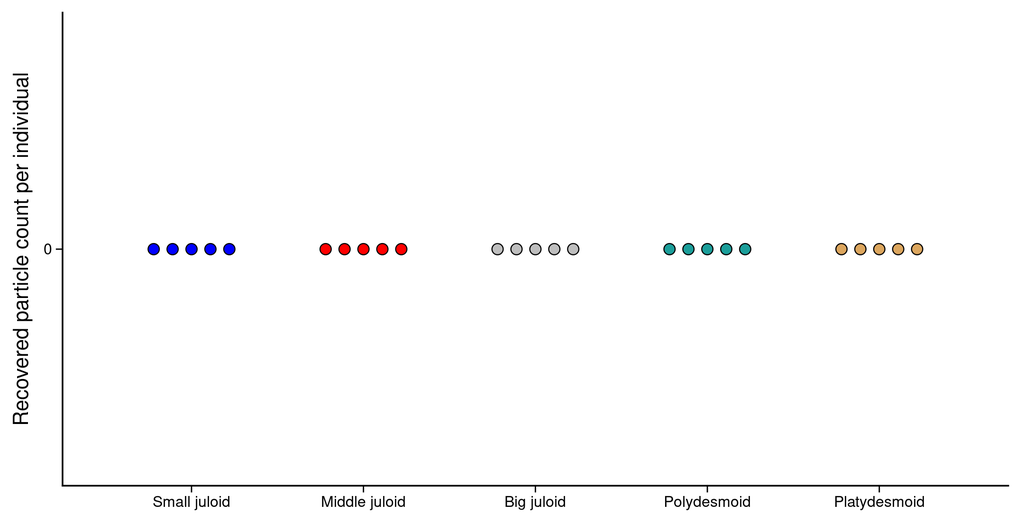

Figure 1. Particle counts in controls: five individuals per life form, all zero.

```r
results$plots$controls
```

## 3.2 Particle recovery, counts and sizes

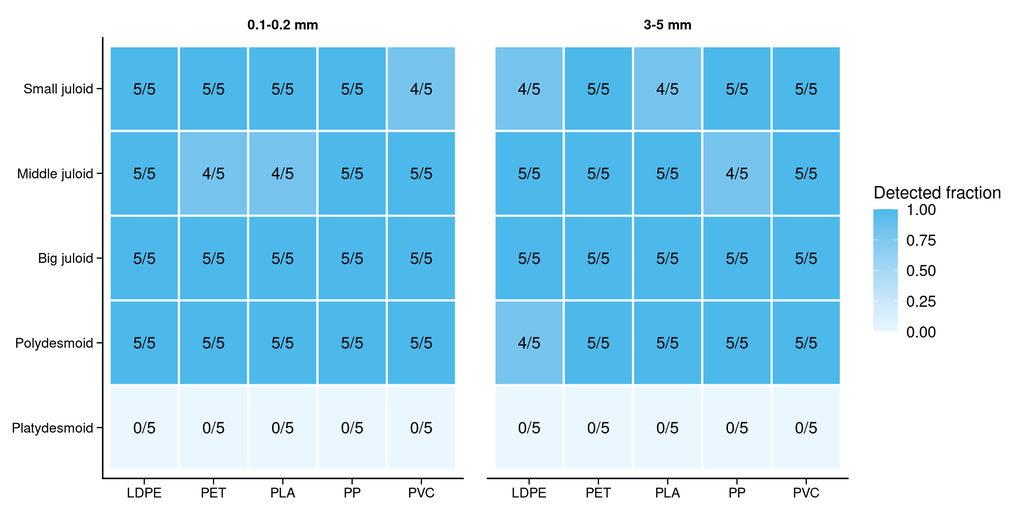

Figure 2. Individuals with recovered particles by life form, polymer and input size. Labels show detected/total individuals (five per cell).

```r
results$plots$detection
```

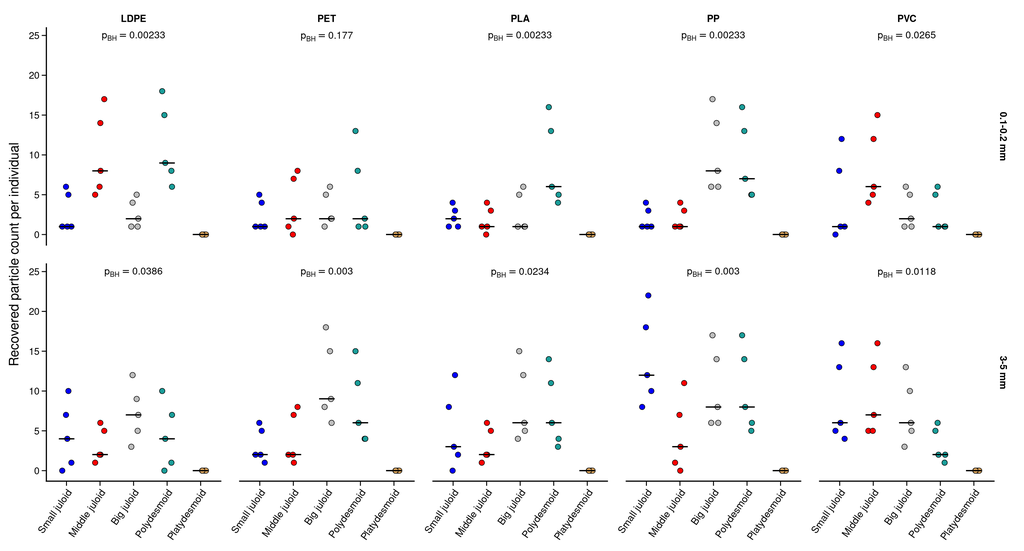

Figure 3. Recovered counts for all 250 experimental individuals; bars show medians. p_BH: omnibus life-form permutation tests within each polymer × input size, adjusted across 10 panels.

```r
results$plots$counts
```

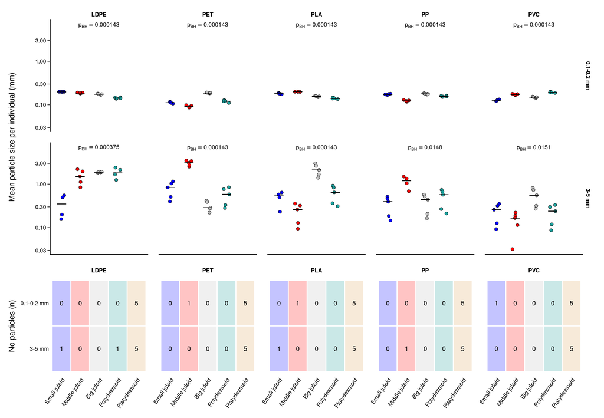

Figure 4. Individual mean particle sizes (log scale) and medians; the lower strip counts individuals without particles. p_BH: omnibus life-form permutation tests on log size within each polymer × input size, adjusted across 10 panels.

```r
results$plots$size
```

```r
show_table(results$summary[!results$summary$is_control,
  c("life_form", "polymer", "input_size_class", "n_individuals", "n_detected",
    "count_mean", "count_sd", "n_size", "size_mean_mm", "size_sd_mm")])
```

| life_form | polymer | input_size_class | n_individuals | n_detected | count_mean | count_sd | n_size | size_mean_mm | size_sd_mm |
| --- | --- | --- | --- | --- | --- | --- | --- | --- | --- |
| small_juloid | LDPE | 0.1-0.2 | 5 | 5 | 2.8 | 2.490 | 5 | 0.198 | 0.001 |
| small_juloid | LDPE | 3-5 | 5 | 4 | 4.4 | 4.159 | 4 | 0.351 | 0.203 |
| small_juloid | PET | 0.1-0.2 | 5 | 5 | 2.4 | 1.949 | 5 | 0.112 | 0.005 |
| small_juloid | PET | 3-5 | 5 | 5 | 3.2 | 2.168 | 5 | 0.786 | 0.326 |
| small_juloid | PLA | 0.1-0.2 | 5 | 5 | 2.2 | 1.304 | 5 | 0.181 | 0.005 |
| small_juloid | PLA | 3-5 | 5 | 4 | 5.0 | 4.899 | 4 | 0.487 | 0.181 |
| small_juloid | PP | 0.1-0.2 | 5 | 5 | 2.0 | 1.414 | 5 | 0.174 | 0.005 |
| small_juloid | PP | 3-5 | 5 | 5 | 14.0 | 5.831 | 5 | 0.340 | 0.165 |
| small_juloid | PVC | 0.1-0.2 | 5 | 4 | 4.4 | 5.320 | 4 | 0.127 | 0.005 |
| small_juloid | PVC | 3-5 | 5 | 5 | 8.8 | 5.357 | 5 | 0.229 | 0.115 |
| middle_juloid | LDPE | 0.1-0.2 | 5 | 5 | 10.0 | 5.244 | 5 | 0.186 | 0.004 |
| middle_juloid | LDPE | 3-5 | 5 | 5 | 3.2 | 2.168 | 5 | 1.525 | 0.566 |
| middle_juloid | PET | 0.1-0.2 | 5 | 4 | 3.6 | 3.647 | 4 | 0.092 | 0.005 |
| middle_juloid | PET | 3-5 | 5 | 5 | 4.0 | 3.240 | 5 | 3.035 | 0.430 |
| middle_juloid | PLA | 0.1-0.2 | 5 | 4 | 1.8 | 1.643 | 4 | 0.198 | 0.001 |
| middle_juloid | PLA | 3-5 | 5 | 5 | 3.2 | 2.168 | 5 | 0.232 | 0.117 |
| middle_juloid | PP | 0.1-0.2 | 5 | 5 | 2.0 | 1.414 | 5 | 0.123 | 0.005 |
| middle_juloid | PP | 3-5 | 5 | 4 | 4.4 | 4.561 | 4 | 1.138 | 0.352 |
| middle_juloid | PVC | 0.1-0.2 | 5 | 5 | 8.4 | 4.827 | 5 | 0.173 | 0.005 |
| middle_juloid | PVC | 3-5 | 5 | 5 | 9.2 | 5.020 | 5 | 0.144 | 0.074 |
| big_juloid | LDPE | 0.1-0.2 | 5 | 5 | 2.6 | 1.817 | 5 | 0.175 | 0.005 |
| big_juloid | LDPE | 3-5 | 5 | 5 | 7.2 | 3.493 | 5 | 1.878 | 0.036 |
| big_juloid | PET | 0.1-0.2 | 5 | 5 | 3.2 | 2.168 | 5 | 0.187 | 0.004 |
| big_juloid | PET | 3-5 | 5 | 5 | 11.2 | 5.070 | 5 | 0.317 | 0.081 |
| big_juloid | PLA | 0.1-0.2 | 5 | 5 | 2.8 | 2.490 | 5 | 0.156 | 0.005 |
| big_juloid | PLA | 3-5 | 5 | 5 | 8.4 | 4.827 | 5 | 2.162 | 0.657 |
| big_juloid | PP | 0.1-0.2 | 5 | 5 | 10.2 | 5.020 | 5 | 0.178 | 0.005 |
| big_juloid | PP | 3-5 | 5 | 5 | 10.2 | 5.020 | 5 | 0.381 | 0.186 |
| big_juloid | PVC | 0.1-0.2 | 5 | 5 | 3.0 | 2.345 | 5 | 0.149 | 0.004 |
| big_juloid | PVC | 3-5 | 5 | 5 | 7.4 | 4.037 | 5 | 0.538 | 0.242 |
| polydesmoid | LDPE | 0.1-0.2 | 5 | 5 | 11.2 | 5.070 | 5 | 0.143 | 0.005 |
| polydesmoid | LDPE | 3-5 | 5 | 4 | 4.4 | 4.159 | 4 | 1.861 | 0.510 |
| polydesmoid | PET | 0.1-0.2 | 5 | 5 | 5.0 | 5.339 | 5 | 0.121 | 0.007 |
| polydesmoid | PET | 3-5 | 5 | 5 | 8.0 | 4.848 | 5 | 0.561 | 0.251 |
| polydesmoid | PLA | 0.1-0.2 | 5 | 5 | 8.8 | 5.357 | 5 | 0.141 | 0.005 |
| polydesmoid | PLA | 3-5 | 5 | 5 | 7.6 | 4.722 | 5 | 0.615 | 0.274 |
| polydesmoid | PP | 0.1-0.2 | 5 | 5 | 9.2 | 5.020 | 5 | 0.157 | 0.005 |
| polydesmoid | PP | 3-5 | 5 | 5 | 10.0 | 5.244 | 5 | 0.491 | 0.238 |
| polydesmoid | PVC | 0.1-0.2 | 5 | 5 | 2.8 | 2.490 | 5 | 0.193 | 0.005 |
| polydesmoid | PVC | 3-5 | 5 | 5 | 3.2 | 2.168 | 5 | 0.215 | 0.108 |
| platydesmoid | LDPE | 0.1-0.2 | 5 | 0 | 0.0 | 0.000 | 0 | NA | NA |
| platydesmoid | LDPE | 3-5 | 5 | 0 | 0.0 | 0.000 | 0 | NA | NA |
| platydesmoid | PET | 0.1-0.2 | 5 | 0 | 0.0 | 0.000 | 0 | NA | NA |
| platydesmoid | PET | 3-5 | 5 | 0 | 0.0 | 0.000 | 0 | NA | NA |
| platydesmoid | PLA | 0.1-0.2 | 5 | 0 | 0.0 | 0.000 | 0 | NA | NA |
| platydesmoid | PLA | 3-5 | 5 | 0 | 0.0 | 0.000 | 0 | NA | NA |
| platydesmoid | PP | 0.1-0.2 | 5 | 0 | 0.0 | 0.000 | 0 | NA | NA |
| platydesmoid | PP | 3-5 | 5 | 0 | 0.0 | 0.000 | 0 | NA | NA |
| platydesmoid | PVC | 0.1-0.2 | 5 | 0 | 0.0 | 0.000 | 0 | NA | NA |
| platydesmoid | PVC | 3-5 | 5 | 0 | 0.0 | 0.000 | 0 | NA | NA |

## 3.3 Omnibus tests and comparison families

```r
show_table(results$omnibus[c("outcome", "polymer", "input_size_class", "n_source", "n",
  "n_groups", "test_statistic", "p_value", "p_bh", "B")], digits = 4)
```

| outcome | polymer | input_size_class | n_source | n | n_groups | test_statistic | p_value | p_bh | B |
| --- | --- | --- | --- | --- | --- | --- | --- | --- | --- |
| output_count | LDPE | 3-5 | 25 | 25 | 5 | 135.3600 | 0.0347 | 0.0386 | 9999 |
| output_count | LDPE | 0.1-0.2 | 25 | 25 | 5 | 492.6400 | 7e-04 | 0.00233 | 9999 |
| output_count | PET | 3-5 | 25 | 25 | 5 | 381.4400 | 0.0012 | 0.003 | 9999 |
| output_count | PET | 0.1-0.2 | 25 | 25 | 5 | 68.1600 | 0.177 | 0.177 | 9999 |
| output_count | PLA | 3-5 | 25 | 25 | 5 | 232.1600 | 0.0164 | 0.0234 | 9999 |
| output_count | PLA | 0.1-0.2 | 25 | 25 | 5 | 223.4400 | 7e-04 | 0.00233 | 9999 |
| output_count | PVC | 3-5 | 25 | 25 | 5 | 317.4400 | 0.0071 | 0.0118 | 9999 |
| output_count | PVC | 0.1-0.2 | 25 | 25 | 5 | 187.8400 | 0.0212 | 0.0265 | 9999 |
| output_count | PP | 3-5 | 25 | 25 | 5 | 607.0400 | 0.0015 | 0.003 | 9999 |
| output_count | PP | 0.1-0.2 | 25 | 25 | 5 | 435.8400 | 7e-04 | 0.00233 | 9999 |
| output_size_mm | LDPE | 3-5 | 25 | 18 | 4 | 9.3450 | 3e-04 | 3.75e-04 | 9999 |
| output_size_mm | LDPE | 0.1-0.2 | 25 | 20 | 4 | 0.2990 | 1e-04 | 1.43e-04 | 9999 |
| output_size_mm | PET | 3-5 | 25 | 20 | 4 | 14.3178 | 1e-04 | 1.43e-04 | 9999 |
| output_size_mm | PET | 0.1-0.2 | 25 | 19 | 4 | 1.2543 | 1e-04 | 1.43e-04 | 9999 |
| output_size_mm | PLA | 3-5 | 25 | 19 | 4 | 13.8346 | 1e-04 | 1.43e-04 | 9999 |
| output_size_mm | PLA | 0.1-0.2 | 25 | 19 | 4 | 0.3167 | 1e-04 | 1.43e-04 | 9999 |
| output_size_mm | PVC | 3-5 | 25 | 20 | 4 | 5.1978 | 0.0151 | 0.0151 | 9999 |
| output_size_mm | PVC | 0.1-0.2 | 25 | 19 | 4 | 0.4421 | 1e-04 | 1.43e-04 | 9999 |
| output_size_mm | PP | 3-5 | 25 | 19 | 4 | 4.3487 | 0.0133 | 0.0148 | 9999 |
| output_size_mm | PP | 0.1-0.2 | 25 | 20 | 4 | 0.4259 | 1e-04 | 1.43e-04 | 9999 |

```r
show_table(results$inference$family_summary, digits = 5)
```

| family | outcome | comparison_axis | n_tested | n_skipped | n_bh_below_0_05 | smallest_raw_p |
| --- | --- | --- | --- | --- | --- | --- |
| output_count__life_form | output_count | life_form | 100 | 0 | 43 | 0.00794 |
| output_count__polymer | output_count | polymer | 100 | 0 | 0 | 0.00794 |
| output_count__input_size | output_count | input_size | 25 | 0 | 0 | 0.00794 |
| output_size_mm__life_form | output_size_mm | life_form | 60 | 40 | 42 | 0.00794 |
| output_size_mm__polymer | output_size_mm | polymer | 80 | 20 | 56 | 0.00794 |
| output_size_mm__input_size | output_size_mm | input_size | 20 | 5 | 13 | 0.00794 |

Overall life-form differences were detected in 19 of 20 panels after BH adjustment. These tests do not identify the particular pairs that differ. Across the six pairwise-test families, 154 of 385 comparisons had p_BH < 0.05; the adjustment applies within each family.

## 3.4 Comparisons between input fractions

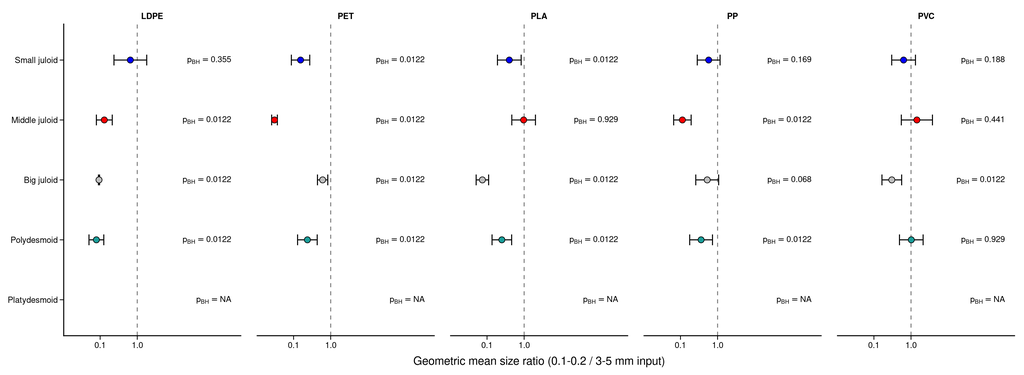

Figure 5. Geometric mean size ratios (0.1–0.2/3–5 mm input), with approximate unadjusted 95% Welch CIs. Permutation p_BH values are adjusted across 20 contrasts; NA indicates undefined size.

```r
results$plots$size_effects
```

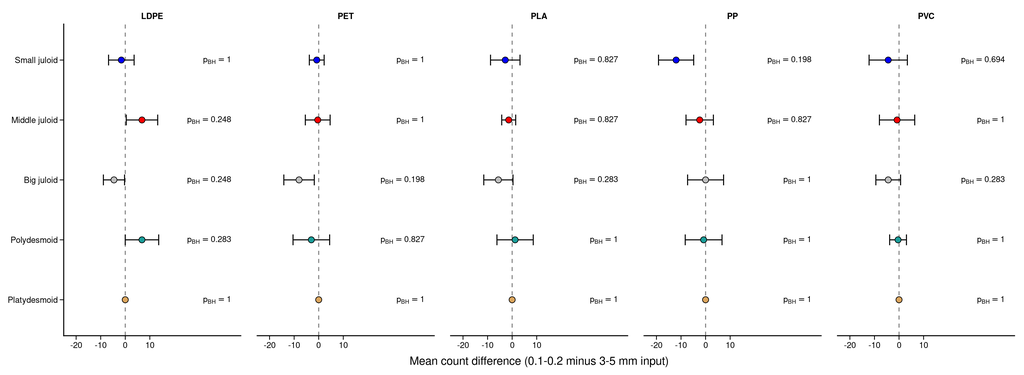

Figure 6. Mean count differences (0.1–0.2 minus 3–5 mm input), with approximate unadjusted 95% Welch CIs. Permutation p_BH values are adjusted across 25 contrasts; constant zero groups have no CI.

```r
results$plots$count_effects
```

## 3.5 Pairwise comparisons of life forms and polymers

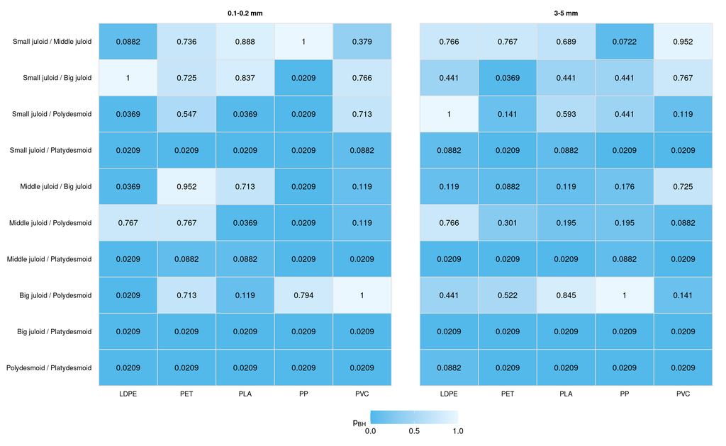

Figure 7. Life-form comparisons of counts within each polymer × input size. Cells show permutation p_BH values, adjusted across all 100 contrasts.

```r
results$plots$count_life_form_pvalues
```

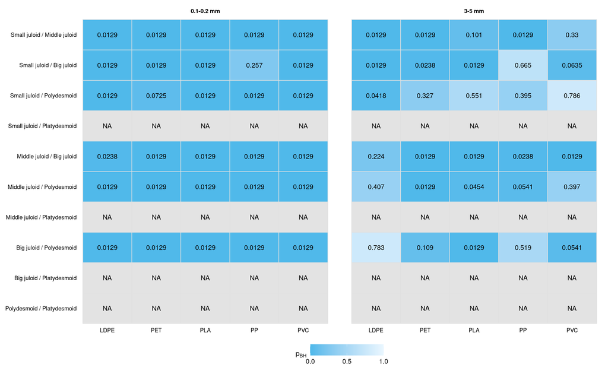

Figure 8. Life-form comparisons of log mean size within each polymer × input size. Cells show permutation p_BH values, adjusted across 60 contrasts; NA indicates undefined size.

```r
results$plots$size_life_form_pvalues
```

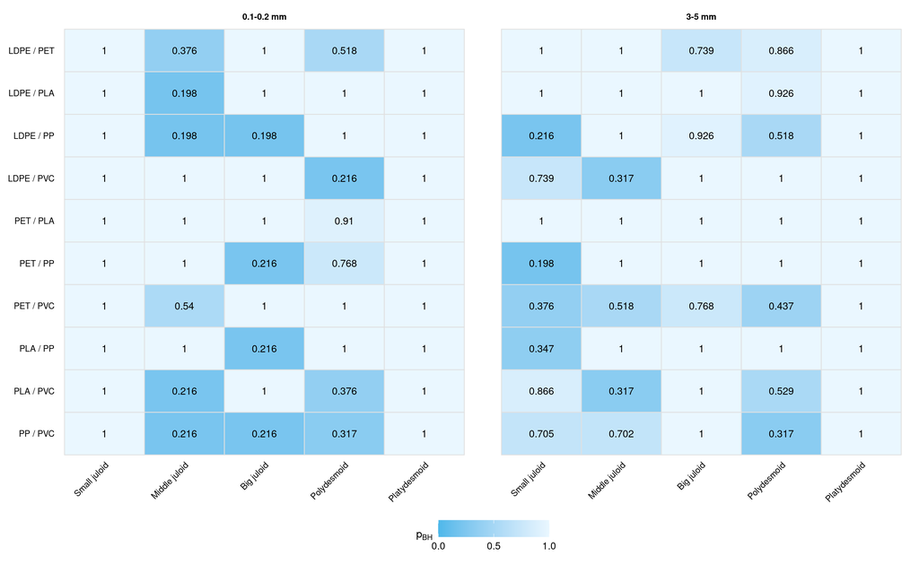

Figure 9. Polymer comparisons of counts within each life form × input size. Cells show permutation p_BH values, adjusted across all 100 contrasts.

```r
results$plots$count_polymer_pvalues
```

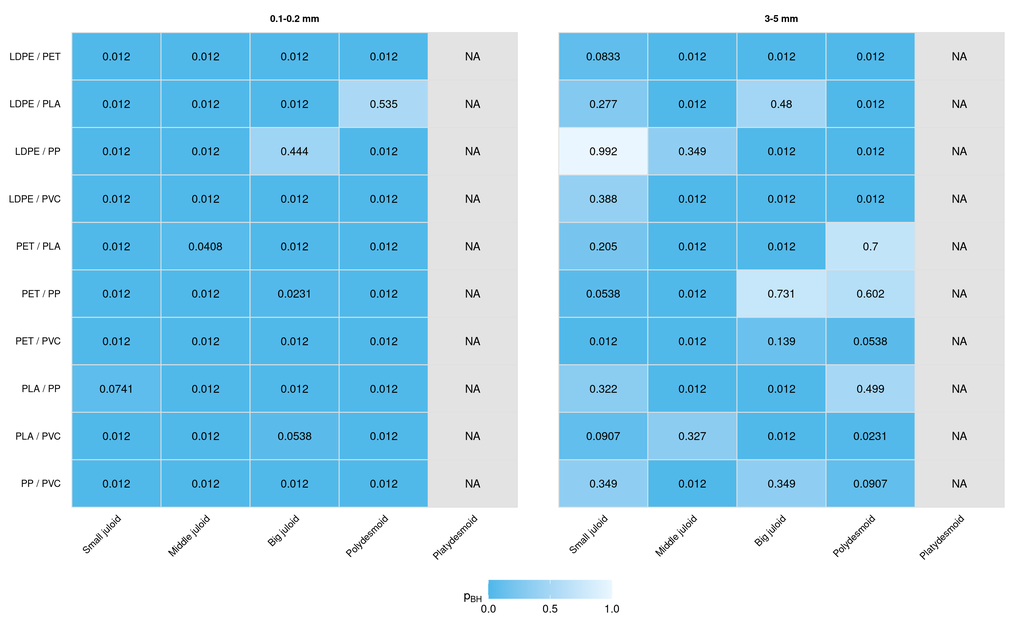

Figure 10. Polymer comparisons of log mean size within each life form × input size. Cells show permutation p_BH values, adjusted across 80 contrasts; NA indicates undefined size.

```r
results$plots$size_polymer_pvalues
```

## 3.6 Complete pairwise results

```r
contrast_columns <- c("outcome", "comparison_axis", "life_form", "polymer", "input_size_class",
  "group_a", "group_b", "n_a", "n_b", "effect", "ci_lower", "ci_upper", "p_value", "p_bh")
show_table(results$inference$contrasts[contrast_columns], digits = 4)
```

| outcome | comparison_axis | life_form | polymer | input_size_class | group_a | group_b | n_a | n_b | effect | ci_lower | ci_upper | p_value | p_bh |
| --- | --- | --- | --- | --- | --- | --- | --- | --- | --- | --- | --- | --- | --- |
| output_count | life_form | NA | LDPE | 3-5 | small_juloid | middle_juloid | 5 | 5 | 1.2000 | -3.9277 | 6.3277 | 0.651 | 0.766 |
| output_count | life_form | NA | LDPE | 3-5 | small_juloid | big_juloid | 5 | 5 | -2.8000 | -8.4305 | 2.8305 | 0.31 | 0.441 |
| output_count | life_form | NA | LDPE | 3-5 | small_juloid | polydesmoid | 5 | 5 | 0.0000 | -6.0661 | 6.0661 | 1 | 1 |
| output_count | life_form | NA | LDPE | 3-5 | small_juloid | platydesmoid | 5 | 5 | 4.4000 | -0.7645 | 9.5645 | 0.0476 | 0.0882 |
| output_count | life_form | NA | LDPE | 3-5 | middle_juloid | big_juloid | 5 | 5 | -4.0000 | -8.3894 | 0.3894 | 0.0714 | 0.119 |
| output_count | life_form | NA | LDPE | 3-5 | middle_juloid | polydesmoid | 5 | 5 | -1.2000 | -6.3277 | 3.9277 | 0.651 | 0.766 |
| output_count | life_form | NA | LDPE | 3-5 | middle_juloid | platydesmoid | 5 | 5 | 3.2000 | 0.5081 | 5.8919 | 0.00794 | 0.0209 |
| output_count | life_form | NA | LDPE | 3-5 | big_juloid | polydesmoid | 5 | 5 | 2.8000 | -2.8305 | 8.4305 | 0.31 | 0.441 |
| output_count | life_form | NA | LDPE | 3-5 | big_juloid | platydesmoid | 5 | 5 | 7.2000 | 2.8631 | 11.5369 | 0.00794 | 0.0209 |
| output_count | life_form | NA | LDPE | 3-5 | polydesmoid | platydesmoid | 5 | 5 | 4.4000 | -0.7645 | 9.5645 | 0.0476 | 0.0882 |
| output_count | life_form | NA | LDPE | 0.1-0.2 | small_juloid | middle_juloid | 5 | 5 | -7.2000 | -13.6297 | -0.7703 | 0.0397 | 0.0882 |
| output_count | life_form | NA | LDPE | 0.1-0.2 | small_juloid | big_juloid | 5 | 5 | 0.2000 | -3.0309 | 3.4309 | 1 | 1 |
| output_count | life_form | NA | LDPE | 0.1-0.2 | small_juloid | polydesmoid | 5 | 5 | -8.4000 | -14.6262 | -2.1738 | 0.0159 | 0.0369 |
| output_count | life_form | NA | LDPE | 0.1-0.2 | small_juloid | platydesmoid | 5 | 5 | 2.8000 | -0.2917 | 5.8917 | 0.00794 | 0.0209 |
| output_count | life_form | NA | LDPE | 0.1-0.2 | middle_juloid | big_juloid | 5 | 5 | 7.4000 | 0.9991 | 13.8009 | 0.0159 | 0.0369 |
| output_count | life_form | NA | LDPE | 0.1-0.2 | middle_juloid | polydesmoid | 5 | 5 | -1.2000 | -8.7235 | 6.3235 | 0.675 | 0.767 |
| output_count | life_form | NA | LDPE | 0.1-0.2 | middle_juloid | platydesmoid | 5 | 5 | 10.0000 | 3.4887 | 16.5113 | 0.00794 | 0.0209 |
| output_count | life_form | NA | LDPE | 0.1-0.2 | big_juloid | polydesmoid | 5 | 5 | -8.6000 | -14.7869 | -2.4131 | 0.00794 | 0.0209 |
| output_count | life_form | NA | LDPE | 0.1-0.2 | big_juloid | platydesmoid | 5 | 5 | 2.6000 | 0.3444 | 4.8556 | 0.00794 | 0.0209 |
| output_count | life_form | NA | LDPE | 0.1-0.2 | polydesmoid | platydesmoid | 5 | 5 | 11.2000 | 4.9054 | 17.4946 | 0.00794 | 0.0209 |
| output_count | life_form | NA | PET | 3-5 | small_juloid | middle_juloid | 5 | 5 | -0.8000 | -4.9249 | 3.3249 | 0.683 | 0.767 |
| output_count | life_form | NA | PET | 3-5 | small_juloid | big_juloid | 5 | 5 | -8.0000 | -14.1949 | -1.8051 | 0.0159 | 0.0369 |
| output_count | life_form | NA | PET | 3-5 | small_juloid | polydesmoid | 5 | 5 | -4.8000 | -10.7305 | 1.1305 | 0.0873 | 0.141 |
| output_count | life_form | NA | PET | 3-5 | small_juloid | platydesmoid | 5 | 5 | 3.2000 | 0.5081 | 5.8919 | 0.00794 | 0.0209 |
| output_count | life_form | NA | PET | 3-5 | middle_juloid | big_juloid | 5 | 5 | -7.2000 | -13.6005 | -0.7995 | 0.0476 | 0.0882 |
| output_count | life_form | NA | PET | 3-5 | middle_juloid | polydesmoid | 5 | 5 | -4.0000 | -10.1698 | 2.1698 | 0.198 | 0.301 |
| output_count | life_form | NA | PET | 3-5 | middle_juloid | platydesmoid | 5 | 5 | 4.0000 | -0.0235 | 8.0235 | 0.00794 | 0.0209 |
| output_count | life_form | NA | PET | 3-5 | big_juloid | polydesmoid | 5 | 5 | 3.2000 | -4.0362 | 10.4362 | 0.381 | 0.522 |
| output_count | life_form | NA | PET | 3-5 | big_juloid | platydesmoid | 5 | 5 | 11.2000 | 4.9054 | 17.4946 | 0.00794 | 0.0209 |
| output_count | life_form | NA | PET | 3-5 | polydesmoid | platydesmoid | 5 | 5 | 8.0000 | 1.9808 | 14.0192 | 0.00794 | 0.0209 |

[output cut: 355 more lines]

An additional 65 size comparisons were unavailable because platydesmoid samples contained no particles. These comparisons were retained in the audit table without p-values. All platydesmoid individuals remained in the count analysis.

## 3.7 Joint variation in particle count and size

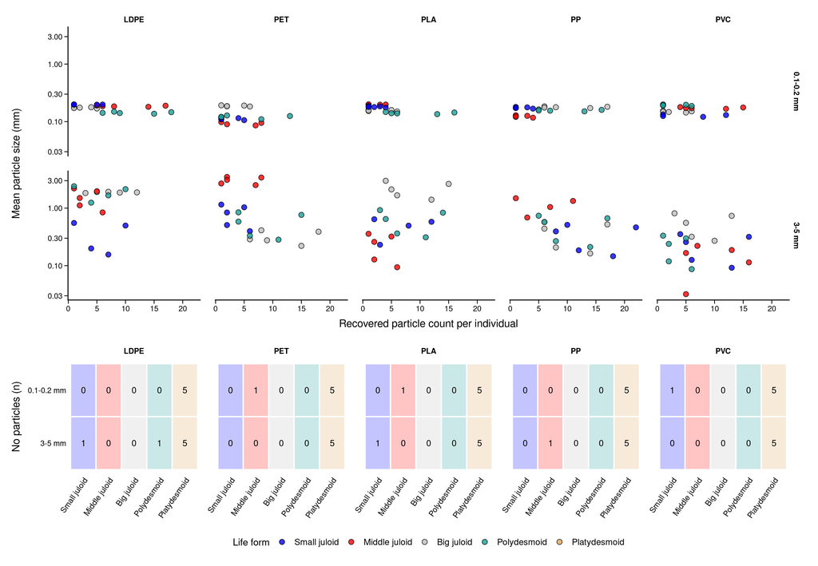

Figure 11. Count versus mean particle size (log scale) among 193 individuals with particles. The lower strip records the 57 individuals without particles.

```r
results$plots$count_size
```

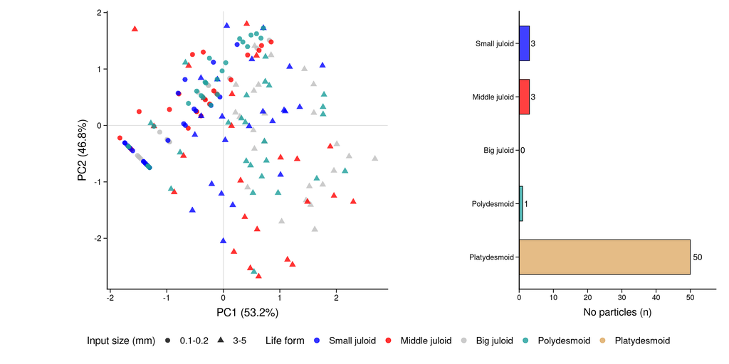

Figure 12. PCA of standardized log1p(count) and log(mean size) for 193 individuals. The adjacent panel counts 57 individuals without particles; their PCA scores are undefined.

```r
results$plots$pca_scores
```

```r
show_table(results$pca$variance)
```

| component | explained_fraction |
| --- | --- |
| PC1 | 0.532 |
| PC2 | 0.468 |

```r
show_table(results$pca$loadings)
```

| variable | PC1 | PC2 |
| --- | --- | --- |
| log_count | 0.707 | 0.707 |
| log_mean_size_mm | 0.707 | -0.707 |

```r
show_table(results$pca$preprocessing)
```

| variable | center | scale |
| --- | --- | --- |
| log_count | 1.723 | 0.710 |
| log_mean_size_mm | -1.239 | 0.953 |

PC1 accounted for 53.2% of the standardized variation. PCA was descriptive; no group significance was inferred from separation in the score plot.

## 3.8 Input ranges and recovered particle sizes

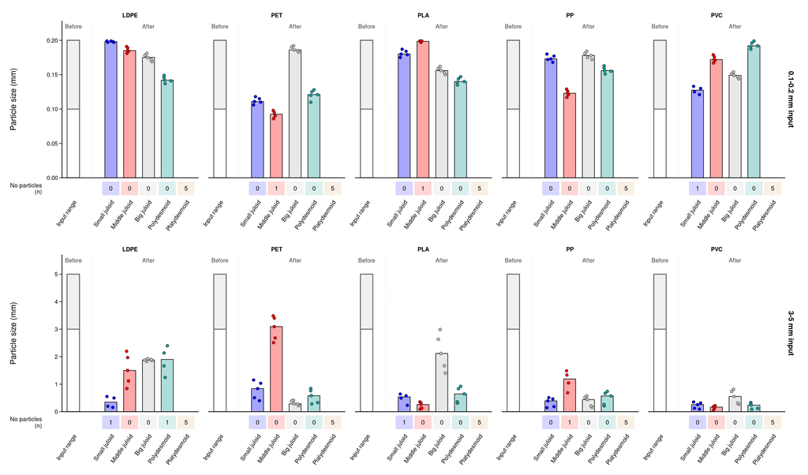

Figure 13. Input-size ranges and recovered particle sizes. Gray segments mark the known 0.1–0.2 and 3–5 mm input ranges; white lower segments extend bars to zero and are not part of those ranges. Recovered-size bars show medians of individual mean sizes, with one jittered point per individual with particles (n = 193). The 57 individuals without particles are counted separately. Rows use different linear y-axis scales. This descriptive comparison does not represent paired measurements before and after ingestion.

```r
results$plots$before_after_size
```

## 3.9 Individual coverage and data checks

```r
coverage <- aggregate(cbind(n_individuals = rep(1L, nrow(exposure)),
  n_no_particles = as.integer(exposure$output_count == 0),
  n_defined_size = as.integer(is.finite(exposure$output_size_mm))),
  by = list(life_form = exposure$life_form), FUN = sum)
show_table(coverage, digits = 0)
```

| life_form | n_individuals | n_no_particles | n_defined_size |
| --- | --- | --- | --- |
| small_juloid | 50 | 3 | 47 |
| middle_juloid | 50 | 3 | 47 |
| big_juloid | 50 | 0 | 50 |
| polydesmoid | 50 | 1 | 49 |
| platydesmoid | 50 | 50 | 0 |

```r
issues <- data_issues
issue_summary <- aggregate(list(n_records = rep(1L, nrow(issues))),
  by = issues[c("issue_code", "severity", "detail", "action")], FUN = sum)
show_table(issue_summary, digits = 0)
```

| issue_code | severity | detail | action | n_records |
| --- | --- | --- | --- | --- |
| control_has_nonzero_input_class | review | The control row contains a nonzero source input-size class. | Classify by MP type=‘control’; set analytical input class and bounds to NA. | 5 |
| zero_count_and_zero_size | information | Count and source size are both zero; size is undefined without particles. | Keep count zero; use NA for analytical particle size. | 82 |

The original input-size label in five middle-juloid controls was retained in the embedded dataset and set to missing in the analytical control metadata. Raw zero size entries were preserved, while analytical mean size was undefined in samples without particles. The report uses the corrected experimental dataset; specimen material, analytical detection limits, treatment allocation and experimental batches require documentation before manuscript submission.

# 4 Reproducibility

## 4.1 Validation code

```r
source("R/data.R")
source("R/inference.R")
source("R/analysis.R")
source("R/figures.R")
source("config.R")
d <- input_data
stopifnot(nrow(d) == 275L, !anyNA(d$sample_id), !anyDuplicated(d$sample_id),
          sum(!d$is_control) == 250L, sum(d$is_control) == 25L,
          all(is.finite(d$output_count)), all(d$output_count >= 0),
          all(d$output_count == floor(d$output_count)),
          all(is.finite(d$output_size_raw)), all(d$output_size_raw >= 0),
          all((d$output_size_raw == 0) == (d$output_count == 0)),
          identical(is.na(d$output_size_mm), d$output_count == 0),
          all(d$output_size_mm[d$output_count > 0] > 0),
          all(d$output_size_mm[d$output_count > 0] == d$output_size_raw[d$output_count > 0]),
          identical(is.na(d$input_size_class), d$is_control),
          identical(is.na(d$input_lower_mm), d$is_control),
          identical(is.na(d$input_upper_mm), d$is_control),
          all(d$is_control == (d$polymer == "control")),
          setequal(d$life_form, life_levels),
          all(table(d$life_form[d$is_control]) == 5L),
          all(d$output_count[d$is_control] == 0L),
          all(d$output_size_raw[d$is_control] == 0))
exposure <- d[!d$is_control, ]
stopifnot(setequal(exposure$polymer, polymer_levels),
          setequal(exposure$input_size_class, c("0.1-0.2", "3-5")),
          all(table(exposure$life_form, exposure$polymer, exposure$input_size_class) == 5L),
          sum(exposure$output_count == 0L) == 57L,
          all(exposure$output_count[exposure$life_form == "platydesmoid"] == 0L),
          all(exposure$input_lower_mm == ifelse(exposure$input_size_class == "0.1-0.2", 0.1, 3)),
          all(exposure$input_upper_mm == ifelse(exposure$input_size_class == "0.1-0.2", 0.2, 5)))
exposure_groups <- interaction(exposure$life_form, exposure$polymer, exposure$input_size_class,
                               drop = TRUE)
for (labels in c(split(exposure$replicate_label, exposure_groups),
                 split(d$replicate_label[d$is_control], d$life_form[d$is_control]))) {
  stopifnot(length(labels) == 5L, setequal(labels, 1:5))
}

t <- mp_permutation_difference(1:5, 6:10)
stopifnot(abs(t$p_value - 2 / choose(10, 5)) < 1e-12,
          t$n_permutations == 252L,
          mp_permutation_difference(rep(0, 5), rep(0, 5))$p_value == 1,
          abs(t$p_value - mp_permutation_difference(6:10, 1:5)$p_value) < 1e-12)
interval <- mp_welch_interval(c(1, 2, 4, 5, 8), c(2, 3, 7, 9, 12))
benchmark <- t.test(c(1, 2, 4, 5, 8), c(2, 3, 7, 9, 12))$conf.int
stopifnot(isTRUE(all.equal(c(interval$lower, interval$upper), as.numeric(benchmark))))

r <- readRDS("results/analysis_results.rds")
stopifnot(identical(r$data$sample_id, d$sample_id),
          identical(r$primary$sample_id, exposure$sample_id))
for (column in names(d)) {
  observed <- r$data[[column]]
  expected <- d[[column]]
  if (is.factor(observed)) observed <- as.character(observed)
  if (is.factor(expected)) expected <- as.character(expected)
  stopifnot(identical(observed, expected))
}
c <- r$inference$contrasts
stopifnot("p_bh" %in% names(c), "p_bh" %in% names(r$omnibus))
for (family in unique(c$family)) {
  use <- c$family == family
  stopifnot(isTRUE(all.equal(c$p_bh[use], p.adjust(c$p_value[use], "BH"))))
}
stopifnot(all(c$p_value > 0 & c$p_value <= 1), all(c$p_bh >= c$p_value - 1e-12),
          all(c$p_bh <= 1),
          abs(sum(r$pca$variance$explained_fraction) - 1) < 1e-12,
          nrow(r$pca$scores) == 193L,
          nrow(r$primary) == 250L,
          sum(r$primary$output_count == 0L) == 57L,
          sum(r$primary$life_form == "platydesmoid") == 50L,
          r$primary$output_count[r$primary$sample_id == "sj pvc 01-02 5"] == 0L,
          identical(r$pca$scores$sample_id, exposure$sample_id[exposure$output_count > 0]))
stopifnot(all(r$omnibus$n[r$omnibus$outcome == "output_count"] == 25L),
          all(r$omnibus$n_groups[r$omnibus$outcome == "output_count"] == 5L),
          all(r$omnibus$n_groups[r$omnibus$outcome == "output_size_mm"] == 4L))
for (outcome in unique(r$omnibus$outcome)) {
  use <- r$omnibus$outcome == outcome
  stopifnot(isTRUE(all.equal(r$omnibus$p_bh[use], p.adjust(r$omnibus$p_value[use], "BH"))))
}
zero_contrasts <- c[c$outcome == "output_count" & c$comparison_axis == "input_size" & c$life_form == "platydesmoid", ]
stopifnot(nrow(zero_contrasts) == 5L, all(zero_contrasts$effect == 0),
          all(zero_contrasts$p_value == 1), all(zero_contrasts$p_bh == 1))

drawn_controls <- ggplot2::ggplot_build(r$plots$controls)$data[[1]]
stopifnot(nrow(drawn_controls) == 25L, all(drawn_controls$y == 0),
          !anyDuplicated(drawn_controls$x))

omnibus_values <- c(1, 3, 2, 8, 9, 7)
omnibus_groups <- rep(c("A", "B"), each = 3L)
set.seed(42)
omnibus_check <- mp_permutation_omnibus(omnibus_values, omnibus_groups, monte_carlo_B = 99L)
group_a <- omnibus_values[omnibus_groups == "A"]
group_b <- omnibus_values[omnibus_groups == "B"]
expected_ss <- length(group_a) * length(group_b) / length(omnibus_values) *
  (mean(group_a) - mean(group_b))^2
stopifnot(abs(omnibus_check$test_statistic - expected_ss) < 1e-12,
          omnibus_check$p_value >= 1 / 100,
          mp_permutation_omnibus(rep(0, 6), omnibus_groups, 99L)$p_value == 1)

plot_sizes <- r$data[!r$data$is_control & !is.na(r$data$output_size_mm), ]
expected_medians <- aggregate(output_size_mm ~ life_form + polymer + input_size_class,
                              data = plot_sizes, FUN = median)$output_size_mm
drawn_medians <- ggplot2::ggplot_build(r$plots$size[[1]])$data[[2]]$y
stopifnot(isTRUE(all.equal(sort(drawn_medians[is.finite(drawn_medians)]),
                          sort(log10(expected_medians)), check.attributes = FALSE)))

check_panel_pvalues <- function(plot, outcome) {
  built <- ggplot2::ggplot_build(plot)
  displayed <- merge(built$data[[3]][c("PANEL", "label")],
    built$layout$layout[c("PANEL", "polymer", "input_size_class")], by = "PANEL")
  expected <- r$omnibus[r$omnibus$outcome == outcome, ]
  expected$label <- mp_p_expression(expected$p_bh)
  compared <- merge(displayed, expected[c("polymer", "input_size_class", "label")],
                    by = c("polymer", "input_size_class"), suffixes = c("_plot", "_test"))
  stopifnot(nrow(compared) == 10L, all(compared$label_plot == compared$label_test))
}
check_panel_pvalues(r$plots$counts, "output_count")
check_panel_pvalues(r$plots$size[[1]], "output_size_mm")

message("Passed: embedded-data integrity, experimental design, zero semantics, exact tests, Welch intervals, family correction and PCA.")
```

All validation checks completed successfully during report rendering.

## 4.2 Software versions

```r
show_table(versions)
```

| package | version |
| --- | --- |
| ggplot2 | 4.0.3 |
| dplyr | 1.2.1 |
| patchwork | 1.3.2 |
| knitr | 1.51 |
| rmarkdown | 2.31 |

## 4.3 Standalone analysis entry point

```r
source("R/data.R", encoding = "UTF-8")
if (!nzchar(Sys.getenv("TZ"))) Sys.setenv(TZ = "UTC")
required <- c("ggplot2", "dplyr", "patchwork")
missing <- required[!vapply(required, requireNamespace, logical(1), quietly = TRUE)]
if (length(missing)) stop("Install required packages with Rscript scripts/install_packages.R: ", paste(missing, collapse = ", "))
suppressPackageStartupMessages(library(ggplot2))
source("config.R", encoding = "UTF-8")
source("R/plot_theme.R", encoding = "UTF-8")
source("R/inference.R", encoding = "UTF-8")
source("R/analysis.R", encoding = "UTF-8")
source("R/figures.R", encoding = "UTF-8")
set.seed(config$seed)
results <- run_analysis(input_data, config)
versions <- data.frame(package = c(required, "knitr", "rmarkdown"),
  version = vapply(c(required, "knitr", "rmarkdown"), function(p) as.character(utils::packageVersion(p)), character(1)))
utils::write.csv(versions, "results/package_versions.csv", row.names = FALSE)
message("Analysis complete: results/tables, results/figures, results/analysis_results.rds")
```

## 4.4 HTML rendering entry point

```r
if (!requireNamespace("rmarkdown", quietly = TRUE)) stop("Run Rscript scripts/install_packages.R first.")
if (!rmarkdown::pandoc_available()) {
  candidates <- c(Sys.getenv("RSTUDIO_PANDOC"),
    "/usr/lib/rstudio/resources/app/bin/quarto/bin/tools/x86_64",
    "/usr/lib/rstudio/resources/app/bin/quarto/bin/tools",
    "/Applications/RStudio.app/Contents/Resources/app/quarto/bin/tools/aarch64")
  found <- candidates[file.exists(file.path(candidates, "pandoc"))]
  if (length(found)) Sys.setenv(RSTUDIO_PANDOC = found[1])
}
if (!rmarkdown::pandoc_available()) stop("Pandoc is required. Install Pandoc or render from RStudio.")
rmarkdown::render("reports/analysis.Rmd", output_file = "analysis.html",
  knit_root_dir = normalizePath("."), envir = new.env(parent = globalenv()), encoding = "UTF-8")
```